# Simulations Based on Parametric Models

Lujun Zhang and Jun Chen

2023-09-21

# 1 Setups

- Required packages:
  - `doParallel`, `foreach`, `doRNG`, `Matrix`, `matrixStats`, `GUniFrac`, `tidyverse`, `data.table`, `Hmisc`, `kableExtra`, `ggpubr` from CRAN;
  - `DESeq2` from bioconductor;
  - `ideas` from https://github.com/Sun-lab/ideas

```r
# library(DESeq2)
library(doParallel)
library(foreach)
library(doRNG)
library(ideas)
library(Matrix)
library(tidyverse)
library(GUniFrac)
library(matrixStats)
library(data.table)
library(kableExtra)
library(ggpubr)

knitr::opts_chunk$set(echo = TRUE)
set.seed(seed = 123456)

# rm(list = ls())
# source("source_code/DiSC.R")
```

# 2 Parametric Simulations: Data Generation

## 2.1 Simulation Design and Related Parameters

The parametric simulation includes the study of 4 scenarios and 3 types of changes. The following code block will generate a text file named “simulation_parameters_{DATE}.txt” containing simulation design parameters in the “para_data_sim/” folder.

- Scenario 1: Increased effect sizes (default 1.3)
- Scenario 2: Increased cell numbers (in real-world data, mean cell number = 375)
- Scenario 3: Increased sample sizes (in real-world data, sample size = 23)
- Scenario 4: No difference. This scenario is designed to examine type I error and FDR.
- We studied three types of changes: difference in mean, difference in variance, and difference in both mean and variance.

```r
# parameter sets
VNCELL = c(FALSE) %>% as.character()
DIFF = c(1.1, 1.2, 1.3, 1.4, 1.5) %>% as.character()
NPG = c(5, 12, 20, 35, 50) %>% as.character() #n per group
NCELL = c(250, 375, 500) %>% as.character()
DATE = "0811" # for version control
# file.create(str_glue("para_data_sim/simulation_parameters_{DATE}.txt"),
#             showWarnings = FALSE )
parameters <- vector(mode = "character", length = 100)
para <- 1

# scenario 1: effect sizes
for(h in 1) #VNCELL
  for(i in 1:length(DIFF)) #DIFF
    for(j in 2) #NCELL
      for(k in 2){ #NPG
        parameters[para] <- str_glue("VNCELL={VNCELL[h]};DIFF={DIFF[i]};NCELL={NCELL[j]};NPG={NPG[k]};BOOT=50")
        para = para+1
      }
# scenario 2: cell number
for(h in 1) #VNCELL
  for(i in 3) #DIFF
    for(j in 1:length(NCELL)) #NCELL
      for(k in 2){ #NPG
        parameters[para] <- str_glue("VNCELL={VNCELL[h]};DIFF={DIFF[i]};NCELL={NCELL[j]};NPG={NPG[k]};BOOT=50")
        para = para+1
      }

# scenario 3: sample sizes
BOOT = 50
for(h in 1) #VNCELL
  for(i in 3) #DIFF
    for(j in 2) #NCELL
      for(k in 1:length(NPG)){ #NPG
        parameters[para] <- str_glue("VNCELL={VNCELL[h]};DIFF={DIFF[i]};NCELL={NCELL[j]};NPG={NPG[k]};BOOT=50")
        para = para+1
      }
# scenario 4: type I error and FDR
parameters[para] <- "VNCELL=FALSE;DIFF=1;NCELL=375;NPG=12;BOOT=1000"
para = para+1

parameters <- parameters[parameters != ""]
parameters <- parameters[!duplicated(parameters)]
parameters
```

```
##  [1] "VNCELL=FALSE;DIFF=1.1;NCELL=375;NPG=12;BOOT=50"
##  [2] "VNCELL=FALSE;DIFF=1.2;NCELL=375;NPG=12;BOOT=50"
##  [3] "VNCELL=FALSE;DIFF=1.3;NCELL=375;NPG=12;BOOT=50"
##  [4] "VNCELL=FALSE;DIFF=1.4;NCELL=375;NPG=12;BOOT=50"
##  [5] "VNCELL=FALSE;DIFF=1.5;NCELL=375;NPG=12;BOOT=50"
##  [6] "VNCELL=FALSE;DIFF=1.3;NCELL=250;NPG=12;BOOT=50"
##  [7] "VNCELL=FALSE;DIFF=1.3;NCELL=500;NPG=12;BOOT=50"
##  [8] "VNCELL=FALSE;DIFF=1.3;NCELL=375;NPG=5;BOOT=50"
##  [9] "VNCELL=FALSE;DIFF=1.3;NCELL=375;NPG=20;BOOT=50"
## [10] "VNCELL=FALSE;DIFF=1.3;NCELL=375;NPG=35;BOOT=50"
## [11] "VNCELL=FALSE;DIFF=1.3;NCELL=375;NPG=50;BOOT=50"
## [12] "VNCELL=FALSE;DIFF=1;NCELL=375;NPG=12;BOOT=1000"
```

```r
para_out <- str_glue("simulation_parameters_{DATE}.txt")
write_file(str_c(parameters, collapse = ":"),
           file = str_glue("para_data_sim/{para_out}"),
           append = FALSE)
```

## 2.2 Parameters that were Estimated from Real Data

The following code block outputs “para_data_sim/setup{DATE}.RData.” The code chunk was modified from the simulation plan in the [IDEAS paper](https://github.com/Sun-lab/ideas_pipeline/blob/main/simulation/step1_simulate_data.R) (Zhang et al., 2022). It starts with the parameters estimated from real-world data (the autism study, Velmeshev et al., 2019) using DCA (Eraslan et al., 2019) at a cell level. It retains the top 8000 abundant genes (approximately, excluding those genes that appear in fewer than 20% of cells). It summarizes cell-level estimations at an individual level for simulation.

Due to file size limitations, the parameters estimated from the autism study (Velmeshev et al., 2019) cannot be uploaded to GitHub. The list of unuploaded files includes “ideas_pipeline-main/Autism/dca_PFC_all/L2_3_dispersion.tsv.gz,” “ideas_pipeline-main/Autism/dca_PFC_all/L2_3_mean.tsv.gz,” and “ideas_pipeline-main/Autism/dca_PFC_all/L2_3_pi.tsv.gz.” The data will be provided upon request; otherwise, the subsequent simulation and analysis can also be resumed with the provided “para_data_sim/setup{DATE}.RData.”

```r
set.seed(seed = 123456)
ngene_2_keep = 8000
signal_density = 0.05
fp = "ideas_pipeline-main/Autism/data/"
DATE = "0811" # for version control

ctp  = "L2_3"
cat("Using cell type:", ctp, "\n")
```

```
## Using cell type: L2_3
```

```r
## count_matrix, genes in rows and cells in columns
count_matrix <- readRDS(file.path(sprintf("%sct_mtx/PFC_%s.rds", fp, ctp)))
ngene <- nrow(count_matrix)
ncell <- ncol(count_matrix)
read_depth <- colSums(count_matrix)
if(ngene < ncell)
  warning("the number of genes is smaller than the number of cells, please check if genes are in rows")
cat("ngene: ", ngene, "ncell: ", ncell, "read_depth[1:10]: ", read_depth[1:10], "\n")
```

```
## ngene:  18041 ncell:  8626 read_depth[1:10]:  8417 23475 11960 7196 3011 5928 33161 10508 10326 5358
```

```r
## Sparsity filtering
sparsity <- rowSums(count_matrix == 0)/ncell
summary(sparsity)
```

```
##    Min. 1st Qu.  Median    Mean 3rd Qu.    Max.
##  0.0000  0.6184  0.8278  0.7396  0.9317  0.9992
```

```r
cat("keep top ", ngene_2_keep, "abundant genes :\n")
```

```
## keep top  8000 abundant genes :
```

```r
gene2keep <- (rank(sparsity) <= ngene_2_keep)
count_matrix <- count_matrix[gene2keep,]
ngene = nrow(count_matrix)
ncell = ncol(count_matrix)
read_depth <- colSums(count_matrix)
sparsity <- rowSums(count_matrix == 0)/ncell
cat("after sparsity filtering, ngene: ", ngene, "ncell: ", ncell, "read_depth[1:10]: ", read_depth[1:10], "\n")
```

```
## after sparsity filtering, ngene:  8000 ncell:  8626 read_depth[1:10]:  7783 21714 11070 6674 2740 5467 30406 9803 9555 4986
```

```r
summary(sparsity)
```

```
##    Min. 1st Qu.  Median    Mean 3rd Qu.    Max.
##  0.0000  0.3869  0.5784  0.5239  0.7042  0.7913
```

```r
## re-sample gene index for differential expression
diff_ngene    <- round(ngene*signal_density)
special_index <- sample.int(ngene, diff_ngene*3)
mean_index    <- as.numeric(special_index[              1 :   diff_ngene])
var_index     <- as.numeric(special_index[(  diff_ngene+1):(2*diff_ngene)])
mean_var_index<- as.numeric(special_index[(2*diff_ngene+1):(3*diff_ngene)])
EE_index      <- (1:ngene)[-special_index]
gene_index <- list(mean_index=mean_index,
                   var_index=var_index,
                   mean_var_index = mean_var_index,
                   EE_index=EE_index)
if(sum(unlist(lapply(gene_index, length))) != ngene)
  stop("number of genes in gene_index != ngene")
if(gene_index[[1]][1] != 3132)
  # gene_index will be used in both simulation and illustration
  warning("the random seed has been changed")
# > gene_index[[1]][1:10]
#  [1] 3132  234 1066 6001 7294 4807 2285 6326 7396 2790

## read in denoised ZINB parameters (DCA model output) of the raw counts
fp = "ideas_pipeline-main/Autism/dca_PFC_all/"
dca_mean = fread(paste(fp, ctp, "_mean.tsv.gz", sep=""))
dca_disp = fread(paste(fp, ctp, "_dispersion.tsv.gz", sep=""))
dca_pi   = fread(paste(fp, ctp, "_pi.tsv.gz", sep="")) # dropout probability
if(sum(dca_mean$V1[gene2keep] != rownames(count_matrix)) == 0){
  t_mean = data.matrix(dca_mean[,-1, with=FALSE])
  t_disp = data.matrix(dca_disp[,-1, with=FALSE])
  t_drop = data.matrix(dca_pi[,-1, with=FALSE])
  rownames(t_mean) = dca_mean$V1
  rownames(t_disp) = dca_disp$V1
  rownames(t_drop) = dca_pi$V1
  t_mean = t_mean[gene2keep,]
  t_disp = t_disp[gene2keep,]
  t_drop = t_drop[gene2keep,]
  rm(dca_mean, dca_disp, dca_pi)
} else stop("dca output does not match count_matrix")

## summarize these parameters at individual level
## we want to estimate the individual_log_mean, individual_log_disp, and
## individual_logit_drop per gene and per individual, by averaging across cells.
## In addition, we want to estimate the sd of individual_log_mean, after
## removing the variation due to read-depth difference.
tapply_median <- function(x){tapply(x, individual_ids, median)}
# median of x at the individual level for each gene
tapply_sd <- function(x){tapply(x, individual_ids, sd)}
individual_ids <- colnames(t_mean) %>%
  str_split(pattern = "_") %>%
  sapply(X=., FUN = function(x){paste(x[-1], collapse="_")})

cell_mean_sum = colSums(t_mean) # sum of ZINB mean in one cell in the denoised data.
cor(cell_mean_sum, colSums(count_matrix)) #0.9988
```

```
## [1] 0.9988079
```

```r
log_t_mean   = log(t(t(t_mean)*(10000/cell_mean_sum))) #denoised mean / cell total
logit_t_drop = log(t_drop/(1 - t_drop))

# remove the variation due to read-depth difference before estimation of the sd
xmt = model.matrix(~log(cell_mean_sum))
log_t_mean_resid = matrix(NA, nrow=nrow(t_mean), ncol=ncol(t_mean))
coef = matrix(NA, nrow=nrow(log_t_mean), ncol=2)
for(i in 1:nrow(log_t_mean)){# for each gene
  yi = log_t_mean[i,]
  li = lm.fit(x=xmt, y=yi)
  coef[i,] = li$coefficients
  log_t_mean_resid[i,] = li$residuals
}

individual_log_mean   = t(apply(log_t_mean,   1, tapply_median))
#median of t_mean at the individual level at each gene
#apply median over different cells in one individual, the index in
#tapply is the invidual index and the rownames of log_t_mean are in
#the form of cellcode_indivual and individual ID. ("AAACCTGCACCCATTC-1_4341_BA46")
individual_log_disp   = t(apply(log(t_disp),  1, tapply_median))
individual_logit_drop = t(apply(logit_t_drop, 1, tapply_median))
individual_log_mean_sd = t(apply(log_t_mean_resid, 1, tapply_sd))
# the sd of log_mean across individuals: it is calculted by
# taking the median of log_mean within individual, and then
# calculate sd across individuals

dim(individual_log_mean) #8000 genes 23 individuals
```

```
## [1] 8000   23
```

```r
individual_log_mean[1:2,1:3]
```

```
##          4341_BA46   5144_PFC   5278_PFC
## DNAJC11 -0.7724552 -0.8480228 -0.6466549
## VPS13D   0.4106566  0.3923179  0.4569656
```

```r
summary(c(individual_log_mean))
```

```
##     Min.  1st Qu.   Median     Mean  3rd Qu.     Max.
## -2.78700 -1.05519 -0.60314 -0.42577  0.01957  6.91461
```

```r
dim(individual_log_disp)
```

```
## [1] 8000   23
```

```r
individual_log_disp[1:2,1:3]
```

```
##         4341_BA46 5144_PFC 5278_PFC
## DNAJC11  1.754619 1.759929 1.769940
## VPS13D   2.178705 2.202396 2.241818
```

```r
summary(c(individual_log_disp))
```

```
##    Min. 1st Qu.  Median    Mean 3rd Qu.    Max.
##  -1.529   1.571   1.757   1.759   1.983   3.114
```

```r
dim(individual_logit_drop)
```

```
## [1] 8000   23
```

```r
individual_logit_drop[1:2,1:3]
```

```
##         4341_BA46  5144_PFC  5278_PFC
## DNAJC11 -2.978319 -2.982070 -2.961410
## VPS13D  -4.890173 -5.104641 -5.276758
```

```r
summary(c(individual_logit_drop))
```

```
##    Min. 1st Qu.  Median    Mean 3rd Qu.    Max.
##  -9.626  -3.967  -2.966  -3.177  -2.244   4.355
```

```r
dim(individual_log_mean_sd)
```

```
## [1] 8000   23
```

```r
individual_log_mean_sd[1:2,1:3]
```

```
##       4341_BA46   5144_PFC   5278_PFC
## [1,] 0.06731425 0.11638343 0.09792350
## [2,] 0.05936775 0.06043058 0.05622031
```

```r
summary(c(individual_log_mean_sd))
```

```
##    Min. 1st Qu.  Median    Mean 3rd Qu.    Max.
## 0.01843 0.09679 0.13542 0.16164 0.20154 0.91996
```

```r
rm(list = c("t_mean", "t_disp", "t_drop",
            "log_t_mean", "log_t_mean_resid", "logit_t_drop"))

## meta_cell to estimate n_cell_obs
fp = "ideas_pipeline-main/Autism/data/"
meta_raw = read_tsv(file.path(fp, "meta.tsv"), col_types = "cffcfnffffnnnndd")
meta_cell <- meta_raw %>% filter(region == "PFC") %>%
  filter(cluster == str_replace(ctp, "_", "/")) %>%
  dplyr::rename(`cell_id` = "cell")
if(sum(!(colnames(count_matrix) %in% meta_cell$cell_id)) >0)
  error("meta_cell and count_matrix dont match") else{
    meta_cell <- meta_cell %>% filter(cell_id %in% colnames(count_matrix))
    if(sum(meta_cell$cell_id != colnames(count_matrix)) >0 )
      error("meta_cell and count_matrix dont match2")
    meta_cell$read_depth <- read_depth
  }
n_cell_obs <- meta_cell %>%
  group_by(individual) %>%
  summarise(n=n()) %>%
  summarise(mean = mean(n), sd = sd(n))
n_cell_obs[["mean"]][1] #375
```

```
## [1] 375.0435
```

```r
## meta_ind
fp = "ideas_pipeline-main/Autism/data/"
meta_raw = read_tsv(file.path(fp, "meta.tsv"), col_types = "cffcfnffffnnnndd")
meta_ind <- meta_raw %>% filter(region == "PFC") %>%
  filter(cluster == str_replace(ctp, "_", "/")) %>%
  distinct(individual, .keep_all = TRUE) %>%
  dplyr::select(-`cell`, -`genes`, -`UMIs`,
                -`RNA mitochondr. percent`,
                -`RNA ribosomal percent`) %>%
  dplyr::rename(RIN = "RNA Integrity Number",
                PMI = "post-mortem interval (hours)")
table(meta_ind$diagnosis)
```

```
##
## Control     ASD
##      10      13
```

```r
## effects of covariates
table(meta_ind$sex, meta_ind$diagnosis)
```

```
##
##     Control ASD
##   M       7  10
##   F       3   3
```

```r
table(meta_ind$Seqbatch, meta_ind$diagnosis)
```

```
##
##       Control ASD
##   SB3       0   0
##   SB2       5   8
##   SB1       5   5
```

```r
table(meta_ind$sample == colnames(individual_log_mean))
```

```
##
## TRUE
##   23
```

```r
pvals = matrix(NA, nrow=ngene, ncol=4)
colnames(pvals) = c("age", "sex", "seqBatch", "RIN")

for(i in 1:ngene){
  yi = individual_log_mean[i,]#individual-level gene expression (median across cells)
  lmi = lm(yi ~ age, data=meta_ind)
  pvals[i,1] = as.numeric(summary(lmi)$coefficients[2,4])

  lmi = lm(yi ~ sex, data=meta_ind)
  pvals[i,2] = as.numeric(summary(lmi)$coefficients[2,4])

  lmi = lm(yi ~ Seqbatch, data=meta_ind)
  pvals[i,3] = as.numeric(summary(lmi)$coefficients[2,4])

  lmi = lm(yi ~ RIN, data=meta_ind)
  pvals[i,4] = as.numeric(summary(lmi)$coefficients[2,4])
}
summary(pvals)# age slightly, sex no, seqBatch & RIN very significant
```

```
##       age              sex               seqBatch             RIN
##  Min.   :0.0000   Min.   :0.0006549   Min.   :0.000000   Min.   :0.0000259
##  1st Qu.:0.1430   1st Qu.:0.2267226   1st Qu.:0.001489   1st Qu.:0.0494523
##  Median :0.3578   Median :0.4580137   Median :0.032004   Median :0.2232029
##  Mean   :0.4060   Mean   :0.4790059   Mean   :0.181615   Mean   :0.3208773
##  3rd Qu.:0.6520   3rd Qu.:0.7310257   3rd Qu.:0.271156   3rd Qu.:0.5470256
##  Max.   :1.0000   Max.   :0.9997916   Max.   :0.999472   Max.   :0.9995703
```

```r
# covariate at the individual level
# first apply a normal quantile transformation to RIN, so that
# later we can simply simulate RIN from standard normal distribution
normscore <- function(vec) {
  len  = length(na.omit(vec))+1
  rank = rank(na.omit(vec))
  ties = (rank - floor(rank)) > 0
  new.vec = vec[!is.na(vec)]
  new.vec[!ties]=qnorm(rank[!ties]/len)
  new.vec[ties] =0.5*(qnorm((rank[ties]+0.5)/len)+qnorm((rank[ties]-0.5)/len))
  vec[!is.na(vec)] = new.vec
  vec
}
RIN.qn <- normscore(meta_ind$RIN)

# estimate 4 parameters for each gene **across individuals** based on
# a multivariate-normal distribution estimation for
# log_mean, log_disp, logit_drop, log of log_mean_sd.
# at the population level, assume the log_mean, disp, mean_sd follows a MVN
# estimate the effects of the normal-quantile-transformed covariate
cov_matrix_list <- vector(mode = "list", length = ngene)
beta_list <- vector(mode = "list", length = ngene)
for (ig in 1:ngene) {# index of gene
  individual_data <- cbind(
    c(individual_log_mean[ig, ]),
    c(individual_log_disp[ig, ]),
    c(individual_logit_drop[ig, ]),
    c(log(individual_log_mean_sd[ig, ]))
  )# 23 rows with the 4 variables

  # individual_data_mean <- apply(individual_data, 2, mean, na.rm = TRUE) # length of 4
  cov_matrix <- cov(individual_data)# the covariance between individual_log_mean,
  #individual_log_disp, individual_logit_drop and individual_log_mean_sd
  cov_matrix_list[[ig]] <- cov_matrix

  log_mean_ig <- individual_data[,1]
  lmi  <- lm(log_mean_ig ~ RIN.qn)
  beta <- lmi$coefficients # beta: how effective RIN (normal) is in log_mean_ig
  beta_list[[ig]] <- beta
}

est_out <- str_glue("setup{DATE}.RData")
save(list = c("gene_index", "cov_matrix_list", "beta_list",
              "individual_log_mean", "individual_log_disp",
              "individual_logit_drop", "individual_log_mean_sd"),
     file = str_glue("para_data_sim/{est_out}"))
```

## 2.3 Set up the Script for Simulations

The following code chunk will generate scripts for high-performance computing, including R and shell scripts, under the folder “para_data_sim”. The code was modified from the simulation plan in the [IDEAS paper](https://github.com/Sun-lab/ideas_pipeline/blob/main/simulation/step1_simulate_data.R) (Zhang et al., 2022).

```r
###########################################################
# When skipping the previous code chunk, run this code
if(!exists("est_out")){
  DATE = "0811" # for version control
  est_out <- str_glue("setup{DATE}.RData")
  load(str_glue("para_data_sim/{est_out}"))
}
###########################################################

DATE = "0811" # version control
WORKINGDIRECTORY = "/home/guanwh/zhan7474/mayo/para_data_sim/"
MEM = 1500 %>% as.character()
NCORE = min(80, round(200000/as.numeric(MEM), digits = -1)) %>% as.character()
para_out
```

```
## simulation_parameters_0811.txt
```

```r
PARA_OUT = para_out
est_out
```

```
## setup0811.RData
```

```r
EST_OUT = est_out

# specify the simulation model
read_file("source_code/gen_sim_data.R") %>%
  str_replace_all(pattern = "DATE", DATE) %>%
  str_replace_all(pattern = "WORKINGDIRECTORY", WORKINGDIRECTORY) %>%
  str_replace_all(pattern = "NCORE", NCORE) %>%
  str_replace_all(pattern = "PARA_OUT", PARA_OUT) %>%
  str_replace_all(pattern = "EST_OUT", EST_OUT) %>%
  write_file(file = str_glue("para_data_sim/gen_sim_data_{DATE}.R"),
             append = FALSE)
# shell file
read_file("source_code/gen_sim_data.sh") %>%
  str_replace_all(pattern = "DATE", DATE) %>%
  str_replace_all(pattern = "WORKINGDIRECTORY", WORKINGDIRECTORY) %>%
  str_replace_all(pattern = "NCORE", NCORE) %>%
  str_replace_all(pattern = "MEM", MEM) %>%
  write_file(file = str_glue("para_data_sim/gen_sim_data_{DATE}.sh"),
             append = FALSE)

simu_d = DATE
```

- Shell script (para_data_sim/gen_sim_data_0811.sh)

```bash
#!/bin/bash
#SBATCH --job-name=gen_d
#SBATCH -o /home/guanwh/zhan7474/mayo/para_data_sim/gen_sim_data_0811.out
#SBATCH -e /home/guanwh/zhan7474/mayo/para_data_sim/gen_sim_data_0811.err
#SBATCH -p msismall
#SBATCH -c 80
#SBATCH --mem-per-cpu=1500
#SBATCH -t 96:00:00

module load R/4.3.0-openblas
Rscript /home/guanwh/zhan7474/mayo/para_data_sim/gen_sim_data_0811.R
```

- R script (para_data_sim/gen_sim_data_0811.R)

```r
##########################
#parameters to be specified:
#genral parameters: /home/guanwh/zhan7474/mayo/para_data_sim/, 80, 0811, simulation_parameters_0811.txt, setup0811.RData
#parameters in model: DIFF, NPG, NCELL, VNCELL, (also BOOT)
##########################
library(tidyverse)
# library(emdbook)
library(MASS)
library(doParallel)
library(foreach)
library(doRNG)

setwd("/home/guanwh/zhan7474/mayo/para_data_sim/")
est_out = "setup0811.RData"
para_out = "simulation_parameters_0811.txt"
dddd = "0811"
load(est_out) #from parameters estimation step
# save(list = c("gene_index", "cov_matrix_list", "beta_list",
#               "individual_log_mean", "individual_log_disp",
#               "individual_logit_drop", "individual_log_mean_sd"),
#      file = str_glue("para_data_sim/{est_out}"))
attach(gene_index)
n_cores = 80
nGeneTotal = sum(unlist(lapply(gene_index, FUN = length)))

# read in paramters
parameters <- read_file(para_out) %>% #from simulation design step
  str_split_1(pattern = ":")
parameters <- parameters[parameters != ""]
parameters <- parameters[!duplicated(parameters)]

# global parallel computing settings
registerDoParallel(cores = n_cores)
options(mc.cores = n_cores)

tryCatch({
  for(paras in parameters){
    set.seed(seed = 12334235)
    eval(parse(text=paras)) # VNCELL=FALSE;DIFF=1.1;NCELL=375;NPG=12;BOOT=50
    boot = BOOT
    diff = exp(abs(log(DIFF))) #promise diff >= 1
    n_cas = NPG
    n_ctr = NPG
    nall = n_cas + n_ctr
    neq_n_cell = VNCELL
    n_cell= NCELL

    # genes that are modified should be the same across each bootstrap
    # (effectively the same for each scenario)
    random_idx_gene <- sample.int(nGeneTotal)
    flag.list <- lapply(gene_index, FUN = function(genes){
      return(sample.int(length(genes)) <= length(genes)/2)
    })

    for(b in 1:boot){ # for FDP calculation, no set.seed inside this loop
      # ------------------------------------------------------------------------
      # estimate 4 parameters for each gene **across individuals** based on
      # a multivariate-normal distribution estimation for
      # log_mean, log_disp, logit_drop, log of log_mean_sd. (Already done)
      # simulate the 4 parameters for each individual
      # ------------------------------------------------------------------------
      # at the population level, assume the log_mean, disp, mean_sd follows a MVN
      par.names <- c("mean", "dispersion", "dropout", "mean_sd")
      indi_para <- array(dim = c(nGeneTotal, nall, 4),
                         dimnames = list(paste("gene", 1:nGeneTotal, sep = "_"),
                                         paste("ind", 1:nall, sep = "_"),
                                         par.names))

      # covariate at the individual level
      # first apply a normal quantile transformation to RIN, so that
      # later we can simply simulate RIN from standard normal distribution
      RIN.simu <- rnorm(nall)

      for (ig in 1:nGeneTotal) {# index of gene
        individual_data <- cbind(
          c(individual_log_mean[ig, ]),
          c(individual_log_disp[ig, ]),
          c(individual_logit_drop[ig, ]),
          c(log(individual_log_mean_sd[ig, ]))
        )# 23 rows with the 4 variables

        individual_data_mean <- apply(individual_data, 2, mean, na.rm = TRUE) # length of 4
        # cov_matrix <- cov(individual_data)# the covariance between individual_log_mean,
        #individual_log_disp, individual_logit_drop and individual_log_mean_sd
        cov_matrix <- cov_matrix_list[[ig]]

        # log_mean_ig <- individual_data[,1]
        # lmi  <- lm(log_mean_ig ~ RIN.qn)
        # beta <- lmi$coefficients # beta: how effective RIN (normal) is in log_mean_ig
        beta <- beta_list[[ig]]

        # add some extra variance for the mean parameter
        e1 <- rnorm(nall, mean=0, sd=sqrt(cov_matrix[1,1]))
        log_mean_ig_simu <- beta[1] + beta[2]*RIN.simu + e1 # simulated RIN covariate

        for(j in 1:nall){
          individual_data_mean_j    <- individual_data_mean
          individual_data_mean_j[1] <- log_mean_ig_simu[j]
          indi_para[ig, j, ]  <- exp(mvrnorm(1, mu = individual_data_mean_j,
                                             Sigma = cov_matrix))
        }# for each gene,
        # for each individual,
        # the mean is correlated with a individual-level RIN + noise,
        # the dispersion, droupout and sd of mean are population-level averages
        # a MVN of the four parameters (one individual one time, looped for each gene).
      }

      # the dropout: expit function, see also the exp part above.
      indi_para[, , 3] <- indi_para[, , 3] / (1 + indi_para[, , 3])

      # shuffle genes and samples
      random_idx_sam <- sample.int(nall)
      RIN.simu <- RIN.simu[random_idx_sam]
      indi_para <- indi_para[random_idx_gene, random_idx_sam, ]
      #random_idx_gene: outside the b in 1:boot loop

      # double check the p-value of the covariate RIN
      # pvals.check = rep(NA, nGeneTotal)
      # for (ig in 1:nGeneTotal) {
      #   y_ig = log(indi_para[ig, , 1]) # mean
      #   lm2  = lm(y_ig ~ RIN.simu)
      #   pvals.check[ig] = summary(lm2)$coef[2,4]
      # }
      # summary(pvals.check)# RIN is highly correlated with the mean

      # ------------------------------------------------------------------------
      # set up parameters for cases and controls
      # ------------------------------------------------------------------------
      # parameterization of ZINB:
      # mu: mean for the NB part; theta: dispersion for the NB part; pi: dropout
      # mean(NB part) = mu
      # var(NB part) = mu + (mu^2)/theta
      # in the "difference in var" scenario, the mean of NB will not be changed.
      # in the "difference in mean" scenario, the variance of NB will still be
      # changed

      individual_param_case <- indi_para[, 1:n_cas, ]
      individual_param_ctrl <- indi_para[, (n_cas + 1):nall, ]
      # # check the mean value parameter across genes
      # rd_case = (colSums(individual_param_case[, , 1]))
      # rd_ctrl = (colSums(individual_param_ctrl[, , 1]))
      # t.test(rd_case, rd_ctrl)# no difference, the read-depths are the same
```

```r
      calc_par_var = function(mu, theta, r_v) {
        # the function calc_par_var returns the over-dispersion parameters
        # for changing the variance of a negative binomial distribution.
        # to make sure theta is larger than 0, r_v should be > 1.
        theta2 = theta  * mu / (mu * r_v + (r_v - 1) * theta)
        if(theta2 < 0){ stop("negative theta2.") }
        theta2
      }

      # mean_index (attach(gene_index) at the start)
      # have half of the genes increased and the other half decreased for balancing
      flag <- flag.list[["mean_index"]]
      # flag[1:10]
      # table(flag)
      k = 0
      for (i in mean_index) {
        k = k + 1
        if(flag[k]){
          for (j in 1:n_cas) {
            individual_param_case[i, j, 1] = individual_param_case[i, j, 1]*diff# fold change
            # individual_param_case[1:5, 1:2, 1] # [genes, individuals, mean]
            # individual_param_ctrl[1:5, 1:2, 1]
          }
        }else{
          for (j in 1:n_ctr) {
            individual_param_ctrl[i, j, 1] = individual_param_ctrl[i, j, 1]*diff
          }
        }
      }
      # flag[1:5]
      # individual_param_case[1:5, 1:2, 1] # genes, individuals, mean
      # individual_param_ctrl[1:5, 1:2, 1]
      #
      # rd_case    = colSums(individual_param_case[, , 1])
      # rd_control = colSums(individual_param_ctrl[, , 1])
      # t.test(rd_case, rd_control)# read depths are still balanced

      # var_index (attach(gene_index) at the start)
      flag <- flag.list[["var_index"]]
      # flag[1:10]
      # table(flag)
      k = 0
      for (i in var_index) {
        k = k + 1
        if(flag[k]){
          for (j in 1:n_cas) {
            x = individual_param_case[i, j, ]
            individual_param_case[i,j,2] =
              calc_par_var(mu = x[1], theta = x[2], r_v = diff)
          }# 2 for dispersion
        }else{
          for (j in 1:n_ctr) {
            x = individual_param_ctrl[i, j, ]
            individual_param_ctrl[i,j,2] =
              calc_par_var(mu = x[1], theta = x[2], r_v = diff)
          }
        }
      }
      # flag[1:5]
      # individual_param_case[1:5, 1:2, 2] # genes, individuals, dispersion
      # individual_param_ctrl[1:5, 1:2, 2]
      # t.test(colSums(individual_param_case[, , 1]),
      #        colSums(individual_param_case[, , 1])) # balanced

      # mean_var_index (attach(gene_index) at the start)
      flag <- flag.list[["mean_var_index"]]
      k = 0
      for (i in mean_var_index) {
        k = k + 1
        if(flag[k]){
          for (j in 1:n_cas) {
            individual_param_case[i, j, 1] = individual_param_case[i, j, 1]*diff# fold change
            x = individual_param_case[i, j, ]
            individual_param_case[i,j,2] =
              calc_par_var(mu = x[1], theta = x[2], r_v = diff)
          }
        }else{
          for (j in 1:n_ctr) {
            individual_param_ctrl[i, j, 1] = individual_param_ctrl[i, j, 1]*diff
            x = individual_param_ctrl[i, j, ]
            individual_param_ctrl[i,j,2] =
              calc_par_var(mu = x[1], theta = x[2], r_v = diff)
          }
        }
      }


      # ------------------------------------------------------------------------
      # simulate scRNAseq based on zinb parameters of cases and controls
      # ------------------------------------------------------------------------
      # Assume first n_cas individuals are cases, the remaining are controls
      # get the number of cells per individual
      n_cell_each <- rnorm(mean = n_cell,
                           sd = ifelse(neq_n_cell, n_cell_obs[["sd"]][1], 0),
                           n = nall) %>% round()
      n_cell_each[n_cell_each < 100] <- 100 # truncated at 100
      n_cell_tot = sum(n_cell_each)
      n_cell_cumsum = c(0, cumsum(n_cell_each))


      sim_matrix = matrix(0, nrow = nGeneTotal, ncol = n_cell_tot)
      for(i in 1:nall){#1:20
        # if(i %% 5 ==0){
        #   cat(i, "\n")
        # }
        idx_i = (n_cell_cumsum[i]+1):(n_cell_cumsum[i+1])
        # the index that these cells belonging to this individual
        if (i > n_cas) {
          mean_i = individual_param_ctrl[, (i - n_cas), 1] # [gene, indi, para]
          #> str(individual_param_ctrl)
          # num [1:3000, 1:10, 1:4] 2.83 7.11 7.99 2.36 5.35 ...
          # - attr(*, "dimnames")=List of 3
          # ..$ : chr [1:3000] "gene_930" "gene_59" "gene_866" "gene_90" ...
          # ..$ : chr [1:10] "ind_19" "ind_1" "ind_6" "ind_12" ...
          # ..$ : chr [1:4] "mean" "dispersion" "dropout" "mean_sd"
          disp_i = individual_param_ctrl[, (i - n_cas), 2]
          drop_i = individual_param_ctrl[, (i - n_cas), 3]
          individual_mean_sd_i = individual_param_ctrl[, (i - n_cas), 4]
        } else{
          mean_i = individual_param_case[, i, 1]
          disp_i = individual_param_case[, i, 2]
          drop_i = individual_param_case[, i, 3]
          individual_mean_sd_i = individual_param_case[, i, 4]
        }

        sim_matrix[,idx_i] =
          foreach(k = 1:(n_cell_each[i]), .combine=cbind) %dorng% {
            #calcualte the each cell "mean" parameter first, using the mean_i and
            #individual_mean_sd_i, for each of the 3000 genes.
            #generate a ZINB random number according to the three parameters
            #(mean, dispersion and droupout)
            #each cell has the mean_i and some variance, and the same
            #dispersion and dropout
            #looped for 3000 genes.
            individual_mean_k = exp(rnorm(n = nGeneTotal, mean = log(mean_i),
                                          sd = individual_mean_sd_i))
            sim_vector_cell_k = rep(NA, nGeneTotal)
            for (ig in 1:nGeneTotal) {
              sim_vector_cell_k[ig] = emdbook::rzinbinom(1, individual_mean_k[ig],
                                                         disp_i[ig], drop_i[ig])
            }
            sim_vector_cell_k
          }
      }
      # dim(sim_matrix)
      # sim_matrix[1:10, 1:5]
      # table(c(sim_matrix) == 0)/(nrow(sim_matrix)*ncol(sim_matrix))
```

```r
      # create meta data

      phenotype  = c(rep(1, sum(n_cell_each[1:n_cas])),
                     rep(0, sum(n_cell_each[(n_cas+1):nall])))
      individual = paste0("ind", c(rep(1:nall, times = n_cell_each)))
      # table(phenotype)
      # sum(n_cell_each[1:10])

      # Count info for matrix
      cell_id = paste0("cell", 1:ncol(sim_matrix))
      gene_id = paste0("gene", 1:nrow(sim_matrix))
      rownames(sim_matrix) <- gene_id
      colnames(sim_matrix) <- cell_id

      # Cell info for meta
      cell_rd = colSums(sim_matrix) # only this change for each boot
      # CDR     = colSums(sim_matrix > 0) / nrow(sim_matrix)
      meta    = data.frame(cell_id, individual, phenotype, cell_rd, #CDR,
                           stringsAsFactors=FALSE)
      # dim(meta)
      # meta[1:2,]

      meta_ind = meta[, c("individual", "phenotype")]
      meta_ind = unique(meta_ind)
      rownames(meta_ind) = meta_ind$individual
      meta_ind$RIN = RIN.simu
      # dim(meta_ind)
      # meta_ind[1:2,]

      mode(sim_matrix) <- "integer"
      dat_list = list(count_matrix = sim_matrix, meta_cell = meta,
                      meta_ind = meta_ind, gene_index = gene_index,
                      random_idx_gene = random_idx_gene)

      save(dat_list, file =
             str_glue("n{n_cas}_{n_ctr}_d{diff}_c{n_cell}_v{neq_n_cell}_{dddd}_b{b}.RData"))

    }# to the next b
  }# to the next parameter set
}, error=function(err){
  # exception handling. See the part above
  # if error occurs, save current work image and restart outside
  message(err)
  message("Need to be restarted...")
  save.image(file = str_glue("unfinished_gen_sim_data_{dddd}.RData"))
  q(save = "no")
  return(0)
})# try-catach part

stopImplicitCluster()
detach(gene_index)
q(save = "no")
```

## 2.4 Generate Simulation Datasets

- Run the scripts above on a super computer
- The scripts will generate a series of simulation data sets “n{n_cas}_{n_ctr}_d{diff}_c{n_cell}*v{neq_n_cell}*{dddd}_b{b}.RData” under the folder “para_data_sim/”

# 3 Paramteric Simulations: Examination of Different Methods

## 3.1 Set up the R and Shell Scripts for an Examination of Different methods

- The following code chunk will generate scripts for high-performance computing, including R script and shell files under the folder “para_data_sim”.
- Simulations are categorized according to their `NPG` (or `n_per_group`), which determines how much memory is required.

```r
DATE = "0811"
WORKINGDIRECTORY = "/home/guanwh/zhan7474/mayo/para_data_sim/"
simu_d
```

```
## [1] "0811"
```

```r
SIMU_D = simu_d
para_out
```

```
## simulation_parameters_0811.txt
```

```r
PARA_OUT = para_out

file.copy(from = "source_code/DiSC.R", to = "para_data_sim/DiSC.R",
          copy.date = TRUE, overwrite  = TRUE)
```

```
## [1] TRUE
```

```r
# file.copy(from = "source_code/exam_sim_data_resume.R",
#           to = str_glue("para_data_sim/exam_sim_data_resume_0805.R"),
#           copy.date = TRUE, overwrite  = TRUE)

METHOD_S = c("disc", "deseq", "ideas")

for(METHOD in METHOD_S){
  # category 1: sample size in [0, 12.1)
  MEM = ifelse(METHOD == "disc", 2500*4, 2500) %>% as.character()
  NCORE = max(5, min(80, round(200000/as.numeric(MEM), digits = -1))) %>% as.character()
  NLIM_1 = 0 %>% as.character()
  NLIM_2 = 12.1 %>% as.character()
  CAT = 1 %>% as.character()
  read_file("source_code/exam_sim_data.sh") %>%
    str_replace_all(pattern = "DATE", DATE) %>%
    str_replace_all(pattern = "WORKINGDIRECTORY", WORKINGDIRECTORY) %>%
    str_replace_all(pattern = "NCORE", NCORE) %>%
    str_replace_all(pattern = "MEM", MEM) %>%
    str_replace_all(pattern = "CAT", CAT) %>%
    str_replace_all(pattern = "METHOD", METHOD) %>%
    write_file(file = str_glue("para_data_sim/exam_sim_data_{CAT}_{METHOD}_{DATE}.sh"),
               append = FALSE)
  # WORKINGDIRECTORY, NCORE, NLIM_1, NLIM_2,
  # PARA_OUT, SIMU_D, CAT
  read_file(str_glue("source_code/exam_sim_data_{METHOD}.R")) %>% # no DATE but SIMU_D!!!
    str_replace_all(pattern = "SIMU_D", SIMU_D) %>%
    str_replace_all(pattern = "WORKINGDIRECTORY", WORKINGDIRECTORY) %>%
    str_replace_all(pattern = "NCORE", NCORE) %>%
    str_replace_all(pattern = "NLIM_1", NLIM_1) %>%
    str_replace_all(pattern = "NLIM_2", NLIM_2) %>%
    str_replace_all(pattern = "PARA_OUT", PARA_OUT) %>%
    str_replace_all(pattern = "CAT", CAT) %>%
    # no METHOD as the script should already have employed "METHOD"
    write_file(file = str_glue("para_data_sim/exam_sim_data_{CAT}_{METHOD}_{DATE}.R"),
               append = FALSE)

  # category 2: sample size in [12.1, 20.1)
  MEM = ifelse(METHOD == "disc", 4000*4, 4000) %>% as.character()
  NCORE = max(5, min(80, round(200000/as.numeric(MEM), digits = -1))) %>% as.character()
  NLIM_1 = 12.1 %>% as.character()
  NLIM_2 = 20.1 %>% as.character()
  CAT = 2 %>% as.character()
  read_file("source_code/exam_sim_data.sh") %>%
    str_replace_all(pattern = "DATE", DATE) %>%
    str_replace_all(pattern = "WORKINGDIRECTORY", WORKINGDIRECTORY) %>%
    str_replace_all(pattern = "NCORE", NCORE) %>%
    str_replace_all(pattern = "MEM", MEM) %>%
    str_replace_all(pattern = "CAT", CAT) %>%
    str_replace_all(pattern = "METHOD", METHOD) %>%
    write_file(file = str_glue("para_data_sim/exam_sim_data_{CAT}_{METHOD}_{DATE}.sh"),
               append = FALSE)
  # WORKINGDIRECTORY, NCORE, NLIM_1, NLIM_2,
  # PARA_OUT, SIMU_D, CAT
  read_file(str_glue("source_code/exam_sim_data_{METHOD}.R")) %>% # no DATE but SIMU_D!!!
    str_replace_all(pattern = "SIMU_D", SIMU_D) %>%
    str_replace_all(pattern = "WORKINGDIRECTORY", WORKINGDIRECTORY) %>%
    str_replace_all(pattern = "NCORE", NCORE) %>%
    str_replace_all(pattern = "NLIM_1", NLIM_1) %>%
    str_replace_all(pattern = "NLIM_2", NLIM_2) %>%
    str_replace_all(pattern = "PARA_OUT", PARA_OUT) %>%
    str_replace_all(pattern = "CAT", CAT) %>%
    # no METHOD as the script should already have employed "METHOD"
    write_file(file = str_glue("para_data_sim/exam_sim_data_{CAT}_{METHOD}_{DATE}.R"),
               append = FALSE)

  # category 3: sample size in [20.1, 35.1)
  MEM = ifelse(METHOD == "disc", 7000*4, 7000) %>% as.character()
  NCORE = max(5, min(80, round(200000/as.numeric(MEM), digits = -1))) %>% as.character()
  NLIM_1 = 20.1 %>% as.character()
  NLIM_2 = 35.1 %>% as.character()
  CAT = 3 %>% as.character()
  read_file("source_code/exam_sim_data.sh") %>%
    str_replace_all(pattern = "DATE", DATE) %>%
    str_replace_all(pattern = "WORKINGDIRECTORY", WORKINGDIRECTORY) %>%
    str_replace_all(pattern = "NCORE", NCORE) %>%
    str_replace_all(pattern = "MEM", MEM) %>%
    str_replace_all(pattern = "CAT", CAT) %>%
    str_replace_all(pattern = "METHOD", METHOD) %>%
    write_file(file = str_glue("para_data_sim/exam_sim_data_{CAT}_{METHOD}_{DATE}.sh"),
               append = FALSE)
  # WORKINGDIRECTORY, NCORE, NLIM_1, NLIM_2,
  # PARA_OUT, SIMU_D, CAT
  read_file(str_glue("source_code/exam_sim_data_{METHOD}.R")) %>% # no DATE but SIMU_D!!!
    str_replace_all(pattern = "SIMU_D", SIMU_D) %>%
    str_replace_all(pattern = "WORKINGDIRECTORY", WORKINGDIRECTORY) %>%
    str_replace_all(pattern = "NCORE", NCORE) %>%
    str_replace_all(pattern = "NLIM_1", NLIM_1) %>%
    str_replace_all(pattern = "NLIM_2", NLIM_2) %>%
    str_replace_all(pattern = "PARA_OUT", PARA_OUT) %>%
    str_replace_all(pattern = "CAT", CAT) %>%
    # no METHOD as the script should already have employed "METHOD"
    write_file(file = str_glue("para_data_sim/exam_sim_data_{CAT}_{METHOD}_{DATE}.R"),
               append = FALSE)

  # category 4: sample size in [35.1, 50.1)
  MEM = ifelse(METHOD == "disc", 10000*4, 10000) %>% as.character()
  NCORE = max(5, min(80, round(200000/as.numeric(MEM), digits = -1))) %>% as.character()
  NLIM_1 = 35.1 %>% as.character()
  NLIM_2 = 50.1 %>% as.character()
  CAT = 4 %>% as.character()
  read_file("source_code/exam_sim_data.sh") %>%
    str_replace_all(pattern = "DATE", DATE) %>%
    str_replace_all(pattern = "WORKINGDIRECTORY", WORKINGDIRECTORY) %>%
    str_replace_all(pattern = "NCORE", NCORE) %>%
    str_replace_all(pattern = "MEM", MEM) %>%
    str_replace_all(pattern = "CAT", CAT) %>%
    str_replace_all(pattern = "METHOD", METHOD) %>%
    write_file(file = str_glue("para_data_sim/exam_sim_data_{CAT}_{METHOD}_{DATE}.sh"),
               append = FALSE)
  # WORKINGDIRECTORY, NCORE, NLIM_1, NLIM_2,
  # PARA_OUT, SIMU_D, CAT
  read_file(str_glue("source_code/exam_sim_data_{METHOD}.R")) %>% # no DATE but SIMU_D!!!
    str_replace_all(pattern = "SIMU_D", SIMU_D) %>%
    str_replace_all(pattern = "WORKINGDIRECTORY", WORKINGDIRECTORY) %>%
    str_replace_all(pattern = "NCORE", NCORE) %>%
    str_replace_all(pattern = "NLIM_1", NLIM_1) %>%
    str_replace_all(pattern = "NLIM_2", NLIM_2) %>%
    str_replace_all(pattern = "PARA_OUT", PARA_OUT) %>%
    str_replace_all(pattern = "CAT", CAT) %>%
    # no METHOD as the script should already have employed "METHOD"
    write_file(file = str_glue("para_data_sim/exam_sim_data_{CAT}_{METHOD}_{DATE}.R"),
               append = FALSE)

  # category T1: Type 1 error rate and FDR
  MEM = ifelse(METHOD == "disc", 2500*4, 2500) %>% as.character()
  NCORE = max(5, min(80, round(200000/as.numeric(MEM), digits = -1))) %>% as.character()
  NLIM_1 = 0 %>% as.character()
  NLIM_2 = 12.1 %>% as.character()
  CAT = "T1" %>% as.character()
  read_file("source_code/exam_sim_data.sh") %>%
    str_replace_all(pattern = "DATE", DATE) %>%
    str_replace_all(pattern = "WORKINGDIRECTORY", WORKINGDIRECTORY) %>%
    str_replace_all(pattern = "NCORE", NCORE) %>%
    str_replace_all(pattern = "MEM", MEM) %>%
    str_replace_all(pattern = "CAT", CAT) %>%
    str_replace_all(pattern = "METHOD", METHOD) %>%
    write_file(file = str_glue("para_data_sim/exam_sim_data_{CAT}_{METHOD}_{DATE}.sh"),
               append = FALSE)
  # WORKINGDIRECTORY, NCORE, NLIM_1, NLIM_2,
  # PARA_OUT, SIMU_D, CAT
  read_file(str_glue("source_code/exam_sim_data_{METHOD}.R")) %>% # no DATE but SIMU_D!!!
    str_replace_all(pattern = "SIMU_D", SIMU_D) %>%
    str_replace_all(pattern = "WORKINGDIRECTORY", WORKINGDIRECTORY) %>%
    str_replace_all(pattern = "NCORE", NCORE) %>%
    str_replace_all(pattern = "NLIM_1", NLIM_1) %>%
    str_replace_all(pattern = "NLIM_2", NLIM_2) %>%
    str_replace_all(pattern = "PARA_OUT", PARA_OUT) %>%
    str_replace_all(pattern = "CAT", CAT) %>%
    # no METHOD as the script should already have employed "METHOD"
    write_file(file = str_glue("para_data_sim/exam_sim_data_{CAT}_{METHOD}_{DATE}.R"),
               append = FALSE)
}


# exam_d = simu_d # simu_d is actually used to denote the results in the script,
# "results" should correspond directly to simulated data
```

- Example shell script (para_data_sim/exam_sim_data_T1_disc_0811.sh)

```bash
#!/bin/bash
#SBATCH --job-name=pasimT1disc
#SBATCH -o /home/guanwh/zhan7474/mayo/para_data_sim/exam_sim_data_T1_disc_0811.out
#SBATCH -e /home/guanwh/zhan7474/mayo/para_data_sim/exam_sim_data_T1_disc_0811.err
#SBATCH -p msismall
#SBATCH -c 20
#SBATCH --mem-per-cpu=10000
#SBATCH -t 96:00:00

source /common/software/install/migrated/anaconda/miniconda3_4.8.3-jupyter/etc/profile.d/conda.sh
conda activate r_env
Rscript /home/guanwh/zhan7474/mayo/para_data_sim/exam_sim_data_T1_disc_0811.R
```

- Example R script for DiSC (para_data_sim/exam_sim_data_T1_disc_0811.R)

```r
##########################
#parameters to be specified:
#general parameters: /home/guanwh/zhan7474/mayo/para_data_sim/, 20, 0, 12.1,
#simulation_parameters_0811.txt, 0811, T1
#parameters in simulations: DIFF, NCELL, NPG, VNCELL
##########################

setwd("/home/guanwh/zhan7474/mayo/para_data_sim/")
library(tidyverse)
library(parallel)

# Need to specify the method when creating this file
method = "disc" # a single value
# be careful, the script assumes to save/return a value called "{method}_pval"
library(Matrix) # specifying package dependencies for the "method"
source("DiSC.R")
# library(doParallel)
# library(ideas)
# library(qvalue)

set.seed(seed = 12345181)
n_cores = 20
n_lim_1 = 0
n_lim_2 = 12.1
DATE = "0811"# the date when simulation datasets were created
para_out = "simulation_parameters_0811.txt"
catgr = "T1"

# read in parameters
parameters <- read_file(para_out) %>%
  str_split_1(pattern = ":")
parameters <- parameters[parameters != ""]
parameters <- parameters[!duplicated(parameters)]
n_per_group_vec <- parameters %>%
  str_extract(pattern = "NPG[:blank:]*=[:blank:]*[:digit:]+") %>%
  str_remove(pattern = "NPG[:blank:]*=[:blank:]*") %>%
  as.numeric()
diff_vec <- parameters %>%
  str_extract(pattern = "DIFF[:blank:]*=[:blank:]*[[:digit:]]+\\.*[[:digit:]]*") %>%
  str_remove(pattern = "DIFF[:blank:]*=[:blank:]*") %>%
  as.numeric()
if(catgr == "T1"){
  parameters <- parameters[diff_vec == 1] # for type I error and FDR
}else{
  parameters <- parameters[n_per_group_vec >= n_lim_1 &
                             n_per_group_vec < n_lim_2 &
                             diff_vec != 1]
}


tryCatch({
  for(paras in parameters){
    eval(parse(text=paras)) # VNCELL=FALSE;DIFF=1.1;NCELL=375;NPG=12;BOOT=50
    boot = BOOT
    diff = exp(abs(log(DIFF))) #promise diff >= 1
    n_cas = NPG
    n_ctr = NPG
    nall = n_cas + n_ctr
    neq_n_cell = VNCELL
    n_cell= NCELL

    conf <- str_glue("n{n_cas}_{n_ctr}_d{diff}_c{n_cell}_v{neq_n_cell}_{DATE}")
    if(file.exists(str_glue("results_{method}_{conf}.RData"))){
      cat(str_glue("finished results_{method}_{conf}.RData\n"))
      next
    }
    if(file.exists(str_glue("unfinished_{method}_{conf}.RData"))){
      # exception handling
      # to resume the previous work
      source("exam_sim_data_resume_disc_0805.R")
      save(list = str_glue("{method}_pval"),
           file = str_glue("results_{method}_{conf}.RData"))
      file.remove(str_glue("unfinished_{method}_{conf}.RData"))
      cat(str_glue("finished results_{method}_{conf}.RData\n"))
      next
    }

    #############DiSC start
    cl <- makeCluster(n_cores)
    clusterExport(cl, c("na.pad", "perm.fdr.adj", "perm.fwer.adj",
                        "DiSC", "basic.func", "conf"))
    clusterEvalQ(cl, {
      library(matrixStats)
      library(tidyverse)
      setwd("/home/guanwh/zhan7474/mayo/para_data_sim/")
    })
    disc_pval <- parSapply(cl, 1:boot, simplify = FALSE, FUN = function(bbbb){
      load(str_glue("{conf}_b{bbbb}.RData"))
      #str(dat_list)
      # nGeneTotal = sum(unlist(lapply(dat_list[["gene_index"]], FUN = length)))
      meta_ind <- dat_list[["meta_ind"]]
      meta_cell <- dat_list[["meta_cell"]]
      count_matrix <- dat_list[["count_matrix"]]
      meta_ind$phenotype <- as.factor(meta_ind$phenotype)
      meta_cell$phenotype <- as.factor(meta_cell$phenotype)


      obj <- DiSC(data.mat = count_matrix,
                  cell.ind = meta_cell,
                  metadata = meta_ind,
                  outcome = "phenotype", covariates = "RIN",
                  cell.id = "cell_id",
                  individual.id = "individual",
                  verbose = FALSE, sequencing.data = TRUE)
      disc_pval_adj <- obj$p.adj.fdr
      disc_pval_raw <- obj$p.raw
      disc_pval <- matrix(c(disc_pval_raw, disc_pval_adj),
                          ncol = 2, byrow = FALSE)
      colnames(disc_pval) <- c("raw", "adjusted")
      return(disc_pval)
    })
    stopCluster(cl)
    ############DiSC completed

    save(list = str_glue("{method}_pval"),
         file = str_glue("results_{method}_{conf}.RData"))
    cat(str_glue("finished results_{method}_{conf}.RData\n"))
  }
}, error=function(err){
  # exception handling. See the part above
  # if error occurs, save current work image and restart outside
  print(err)
  print("Need to be restarted...")
  save.image(file = str_glue("unfinished_{method}_{conf}.RData"))
  q(save = "no")
  return(0)
})# try-catach part

q(save = "no")
```

- Example R script for IDEAS (para_data_sim/exam_sim_data_T1_ideas_0811.R)

```r
##########################
#parameters to be specified:
#general parameters: /home/guanwh/zhan7474/mayo/para_data_sim/, 80, 0, 12.1,
#simulation_parameters_0811.txt, 0811, T1
#parameters in simulations: DIFF, NCELL, NPG, VNCELL
##########################

setwd("/home/guanwh/zhan7474/mayo/para_data_sim/")
library(tidyverse)
library(parallel)

# Need to specify the method when creating this file
method = "ideas" # a single value
# be careful, the script assumes to save/return a value called "{method}_pval"
library(ideas) # specifying package dependencies for the "method"
library(qvalue)
library(doParallel)
# source("DiSC.R")
# library(doParallel)
# library(ideas)
# library(qvalue)

set.seed(seed = 12345181)
n_cores = 80
n_lim_1 = 0
n_lim_2 = 12.1
DATE = "0811"# the date when simulation datasets were created
para_out = "simulation_parameters_0811.txt"
catgr = "T1"

# read in parameters
parameters <- read_file(para_out) %>%
  str_split_1(pattern = ":")
parameters <- parameters[parameters != ""]
parameters <- parameters[!duplicated(parameters)]
n_per_group_vec <- parameters %>%
  str_extract(pattern = "NPG[:blank:]*=[:blank:]*[:digit:]+") %>%
  str_remove(pattern = "NPG[:blank:]*=[:blank:]*") %>%
  as.numeric()
diff_vec <- parameters %>%
  str_extract(pattern = "DIFF[:blank:]*=[:blank:]*[[:digit:]]+\\.*[[:digit:]]*") %>%
  str_remove(pattern = "DIFF[:blank:]*=[:blank:]*") %>%
  as.numeric()
if(catgr == "T1"){
  parameters <- parameters[diff_vec == 1] # for type I error and FDR
}else{
  parameters <- parameters[n_per_group_vec >= n_lim_1 &
                             n_per_group_vec < n_lim_2 &
                             diff_vec != 1]
}


tryCatch({
  for(paras in parameters){
    eval(parse(text=paras)) # VNCELL=FALSE;DIFF=1.1;NCELL=375;NPG=12;BOOT=50
    boot = BOOT
    diff = exp(abs(log(DIFF))) #promise diff >= 1
    n_cas = NPG
    n_ctr = NPG
    nall = n_cas + n_ctr
    neq_n_cell = VNCELL
    n_cell= NCELL

    conf <- str_glue("n{n_cas}_{n_ctr}_d{diff}_c{n_cell}_v{neq_n_cell}_{DATE}")
    if(file.exists(str_glue("results_{method}_{conf}.RData"))){
      cat(str_glue("finished results_{method}_{conf}.RData\n"))
      next
    }
    if(file.exists(str_glue("unfinished_{method}_{conf}.RData"))){
      # exception handling
      # to resume the previous work
      source("exam_sim_data_resume_disc_0805.R")
      save(list = str_glue("{method}_pval"),
           file = str_glue("results_{method}_{conf}.RData"))
      file.remove(str_glue("unfinished_{method}_{conf}.RData"))
      cat(str_glue("finished results_{method}_{conf}.RData\n"))
      next
    }

    ############ideas starts
    ideas_pval <- vector(mode = "list", length = boot)
    registerDoParallel(cores=n_cores)
    options(mc.cores=n_cores)
    RNGkind("L'Ecuyer-CMRG")
    for(bbbb in 1:boot){
      tryCatch(
        {
          load(str_glue("{conf}_b{bbbb}.RData"))
          #str(dat_list)
          # nGeneTotal = sum(unlist(lapply(dat_list[["gene_index"]], FUN = length)))
          meta_ind <- dat_list[["meta_ind"]]
          meta_cell <- dat_list[["meta_cell"]]
          count_matrix <- dat_list[["count_matrix"]]
          meta_ind$phenotype <- as.factor(meta_ind$phenotype)
          meta_cell$phenotype <- as.factor(meta_cell$phenotype)

          # rate-limiting step
          dist1 <- ideas_dist(count_input = count_matrix,
                              meta_cell = meta_cell, meta_ind = meta_ind,
                              var_per_cell = "cell_rd", var2test = "phenotype",
                              var2test_type = "binary",
                              d_metric = "Was", fit_method = "nb")
          ideas_pval_raw <- permanova(dist_array = dist1, meta_ind = meta_ind,
                                      var2test = "phenotype", var2adjust = "RIN",
                                      var2test_type = "binary", n_perm=999)
          recal_index <- which(ideas_pval_raw < 0.01)# NA values will be excluded
          if(length(recal_index) > 0){
            if (length(recal_index) == 1){
              slice_dist <- dist1[recal_index, , ]
              recal_dist <- array(dim = c(1, dim(slice_dist)))
              recal_dist[1, , ] <- slice_dist
            }else{
              recal_dist <- dist1[recal_index, , ]
            }
            # diff = exp(abs(log(DIFF))) #promise diff >= 1
            # n_cas = NPG
            # n_ctr = NPG
            # nall = n_cas + n_ctr
            # neq_n_cell = VNCELL
            # n_cell= NCELL
            ideas_pval_raw_r <- permanova(dist_array = recal_dist,
                                          meta_ind = meta_ind,
                                          var2test = "phenotype",
                                          var2adjust = "RIN",
                                          var2test_type = "binary",
                                          n_perm=ifelse(diff<=1.2|nall<=10|n_cell<=250,
                                                        99999, 9999))
            # when the power is too low, we need more permutations for q-value
            ideas_pval_raw[recal_index] <- ideas_pval_raw_r
          }

          pval_temp <- ideas_pval_raw
          pi0 = 2*sum(pval_temp > 0.5, na.rm = TRUE)/sum(!is.na(pval_temp))
          # really need this pi0, otherwise in some cases, error will occur
          pi0 = ifelse(pi0>1, 1, ifelse(pi0<0.5, 0.5, pi0)) # 0.5<=pi0<=1
          ideas_pval_adj <- qvalue(pval_temp, pi0=pi0)$qvalues
          ideas_pval[[bbbb]]  <- matrix(c(ideas_pval_raw, ideas_pval_adj),
                                        ncol = 2, byrow = FALSE,
                                        dimnames = list(NULL,
                                                        c("raw", "adjusted")))
          gc()
        },
        error = function(err){
          #due to the terrible garbage collection features in R, the pro-
          #gram may stop occasionally and irreproducibly.
          #in this case, try to restart the P-value calculation and resume the job
          print(err)
          print("Try to restart...")
          stopImplicitCluster()

          registerDoParallel(cores=n_cores)
          # it seems the nodes registered inside the function are still accessible
          #outside
          options(mc.cores=n_cores)
          RNGkind("L'Ecuyer-CMRG")

          load(str_glue("{conf}_b{bbbb}.RData"))
          #str(dat_list)
          # nGeneTotal = sum(unlist(lapply(dat_list[["gene_index"]], FUN = length)))
          meta_ind <- dat_list[["meta_ind"]]
          meta_cell <- dat_list[["meta_cell"]]
          count_matrix <- dat_list[["count_matrix"]]
          meta_ind$phenotype <- as.factor(meta_ind$phenotype)
          meta_cell$phenotype <- as.factor(meta_cell$phenotype)

          # rate-limiting step
          dist1 <- ideas_dist(count_input = count_matrix,
                              meta_cell = meta_cell, meta_ind = meta_ind,
                              var_per_cell = "cell_rd", var2test = "phenotype",
                              var2test_type = "binary",
                              d_metric = "Was", fit_method = "nb")
          ideas_pval_raw <- permanova(dist_array = dist1, meta_ind = meta_ind,
                                      var2test = "phenotype", var2adjust = "RIN",
                                      var2test_type = "binary", n_perm=999)
          recal_index <- which(ideas_pval_raw < 0.01)# NA values will be excluded
          if(length(recal_index) > 0){
            if (length(recal_index) == 1){
              slice_dist <- dist1[recal_index, , ]
              recal_dist <- array(dim = c(1, dim(slice_dist)))
              recal_dist[1, , ] <- slice_dist
            }else{
              recal_dist <- dist1[recal_index, , ]
            }
            ideas_pval_raw_r <- permanova(dist_array = recal_dist,
                                          meta_ind = meta_ind,
                                          var2test = "phenotype",
                                          var2adjust = "RIN",
                                          var2test_type = "binary", n_perm=9999)
            ideas_pval_raw[recal_index] <- ideas_pval_raw_r
          }

          pval_temp <- ideas_pval_raw
          pi0 = 2*sum(pval_temp > 0.5, na.rm = TRUE)/sum(!is.na(pval_temp))
          # really need this pi0, otherwise in some cases, error will occur
          pi0 = ifelse(pi0>1, 1, ifelse(pi0<0.5, 0.5, pi0)) # 0.5<=pi0<=1
          ideas_pval_adj <- qvalue(pval_temp, pi0=pi0)$qvalues

          ideas_pval[[bbbb]] <<- matrix(c(ideas_pval_raw, ideas_pval_adj),
                                        ncol = 2, byrow = FALSE,
                                        dimnames = list(NULL,
                                                        c("raw", "adjusted")))
          gc()

          print("Restarted successfully. Continue...")

          return(0)
        }
      )
    }
    stopImplicitCluster()
    ############IDEAS completed

    save(list = str_glue("{method}_pval"),
         file = str_glue("results_{method}_{conf}.RData"))
    cat(str_glue("finished results_{method}_{conf}.RData\n"))
  }
}, error=function(err){
  # exception handling. See the part above
  # if error occurs, save current work image and restart outside
  print(err)
  print("Need to be restarted...")
  save.image(file = str_glue("unfinished_{method}_{conf}.RData"))
  q(save = "no")
  return(0)
})# try-catach part

q(save = "no")
```

- Example R script for DESeq2 (para_data_sim/exam_sim_data_T1_deseq_0811.R)

```r
##########################
#parameters to be specified:
#general parameters: /home/guanwh/zhan7474/mayo/para_data_sim/, 80, 0, 12.1,
#simulation_parameters_0811.txt, 0811, T1
#parameters in simulations: DIFF, NCELL, NPG, VNCELL
##########################

setwd("/home/guanwh/zhan7474/mayo/para_data_sim/")
library(tidyverse)
library(parallel)

# Need to specify the method when creating this file
method = "deseq" # a single value
# be careful, the script assumes to save/return a value called "{method}_pval"
require(DESeq2) # specifying package dependencies for the "method"
# source("DiSC.R")
# library(doParallel)
# library(ideas)
# library(qvalue)

set.seed(seed = 12345181)
n_cores = 80
n_lim_1 = 0
n_lim_2 = 12.1
DATE = "0811"# the date when simulation datasets were created
para_out = "simulation_parameters_0811.txt"
catgr = "T1"

# read in parameters
parameters <- read_file(para_out) %>%
  str_split_1(pattern = ":")
parameters <- parameters[parameters != ""]
parameters <- parameters[!duplicated(parameters)]
n_per_group_vec <- parameters %>%
  str_extract(pattern = "NPG[:blank:]*=[:blank:]*[:digit:]+") %>%
  str_remove(pattern = "NPG[:blank:]*=[:blank:]*") %>%
  as.numeric()
diff_vec <- parameters %>%
  str_extract(pattern = "DIFF[:blank:]*=[:blank:]*[[:digit:]]+\\.*[[:digit:]]*") %>%
  str_remove(pattern = "DIFF[:blank:]*=[:blank:]*") %>%
  as.numeric()
if(catgr == "T1"){
  parameters <- parameters[diff_vec == 1] # for type I error and FDR
}else{
  parameters <- parameters[n_per_group_vec >= n_lim_1 &
                             n_per_group_vec < n_lim_2 &
                             diff_vec != 1]
}


tryCatch({
  for(paras in parameters){
    eval(parse(text=paras)) # VNCELL=FALSE;DIFF=1.1;NCELL=375;NPG=12;BOOT=50
    boot = BOOT
    diff = exp(abs(log(DIFF))) #promise diff >= 1
    n_cas = NPG
    n_ctr = NPG
    nall = n_cas + n_ctr
    neq_n_cell = VNCELL
    n_cell= NCELL

    conf <- str_glue("n{n_cas}_{n_ctr}_d{diff}_c{n_cell}_v{neq_n_cell}_{DATE}")
    if(file.exists(str_glue("results_{method}_{conf}.RData"))){
      cat(str_glue("finished results_{method}_{conf}.RData\n"))
      next
    }
    if(file.exists(str_glue("unfinished_{method}_{conf}.RData"))){
      # exception handling
      # to resume the previous work
      source("exam_sim_data_resume_disc_0805.R")
      save(list = str_glue("{method}_pval"),
           file = str_glue("results_{method}_{conf}.RData"))
      file.remove(str_glue("unfinished_{method}_{conf}.RData"))
      cat(str_glue("finished results_{method}_{conf}.RData\n"))
      next
    }

    ############pseudo-bulk method, DESeq2 starts
    cl <- makeCluster(n_cores)
    clusterExport(cl, c("conf"))
    clusterEvalQ(cl, {
      library(stringr)
      library(DESeq2)
      setwd("/home/guanwh/zhan7474/mayo/para_data_sim/")
    })
    deseq_pval <- parSapply(cl, 1:boot, simplify = FALSE, FUN = function(bbbb){
      load(str_glue("{conf}_b{bbbb}.RData"))
      #str(dat_list)
      # nGeneTotal = sum(unlist(lapply(dat_list[["gene_index"]], FUN = length)))
      meta_ind <- dat_list[["meta_ind"]]
      meta_cell <- dat_list[["meta_cell"]]
      count_matrix <- dat_list[["count_matrix"]]
      meta_ind$phenotype <- as.factor(meta_ind$phenotype)
      meta_cell$phenotype <- as.factor(meta_cell$phenotype)

      # prepossing
      count_matrix_bulk = matrix(NA, nrow = nrow(count_matrix),
                                 ncol = nrow(meta_ind))
      rownames(count_matrix_bulk) = rownames(count_matrix)
      colnames(count_matrix_bulk) = meta_ind[["individual"]]
      if(sum(meta_cell[["cell_id"]] != colnames(count_matrix))==0)
        for (i_ind in 1:length(meta_ind[["individual"]])) {
          cur_ind   = meta_ind[["individual"]][i_ind]
          cur_ind_m = count_matrix[, meta_cell[["individual"]] == cur_ind]
          count_matrix_bulk[, i_ind] = rowSums(cur_ind_m, na.rm = TRUE)
        }else
          stop("meta_cell$cell_id and colnames(count_matrix) dont match")

      dds <- DESeq2::DESeqDataSetFromMatrix(countData = count_matrix_bulk,
                                            colData = meta_ind,
                                            design = ~ RIN + phenotype)
      dds <- DESeq2::DESeq(dds, quiet = TRUE)
      deseq_pval_adj <- DESeq2::results(dds, name = "phenotype_1_vs_0")$padj
      deseq_pval_adj[is.na(deseq_pval_adj)] <- 1
      # when allowing independentFiltering and cooksCutoff, p-values for some
      # genes may be returned as NA. Set them to an insignificant p-value.
      deseq_pval_raw <- DESeq2::results(dds, name = "phenotype_1_vs_0")$pvalue
      deseq_pval_raw[is.na(deseq_pval_raw)] <- 1
      # the default method for adjusting for multiplicity is BH in DESeq
      #When disabling independentFiltering and cooksCutoff:
      #identical(p.adjust(deseq_pval_raw, method = "BH"), deseq_pval_adj)#TRUE
      deseq_pval <- matrix(c(deseq_pval_raw, deseq_pval_adj),
                           ncol = 2, byrow = FALSE)
      colnames(deseq_pval) <- c("raw", "adjusted")

      return(deseq_pval)
    })
    stopCluster(cl)
    ############DESeq2 completed

    save(list = str_glue("{method}_pval"),
         file = str_glue("results_{method}_{conf}.RData"))
    cat(str_glue("finished results_{method}_{conf}.RData\n"))
  }
}, error=function(err){
  # exception handling. See the part above
  # if error occurs, save current work image and restart outside
  print(err)
  print("Need to be restarted...")
  save.image(file = str_glue("unfinished_{method}_{conf}.RData"))
  q(save = "no")
  return(0)
})# try-catach part

q(save = "no")
```

## 3.2 Examining the Association between Treatment and Transcriptomic profiles using Different Methods

Run the scripts above on a supercomputer to test the association between phenotype and simulated single-cell RNA sequencing data. The results will be saved as ’results_{method}*n{n_cas}*{n_ctr}_d{diff}_c{n_cell}v{neq_n_cell}{DATE}.RData.’

# 4 Paramteric Simulations: Results

## 4.1 Combining results from different scenarios

Summarizing results and investigating the type I error, false discovery rate (FDR) and/or false discovery proportions (FDP), and the number of true positive findings using adjusted and unadjusted P-values from different methods.

```r
# simu_d is actually used to denote the results in the script above,
# "results" should correspond directly to simulated data
DATE = simu_d
thre_raw = 0.05
thre_adj = 0.10
METHOD_S = c("DiSC" = "disc", "IDEAS" = "ideas", "DESeq2" = "deseq")
meths = names(METHOD_S) # displayed name

summarize_binconf <- function(x, repl){
  # calculate the binomial confidence interval with x successes and repl trials
  # returns a string
  CI_95 <- Hmisc::binconf(x = x, n = repl, method=c("wilson"))
  CI_95 <- round(CI_95*100, digits = 1)
  CI_95 <- paste(CI_95[,"PointEst"]," (", CI_95[,"Lower"],
                 ", ", CI_95[,"Upper"],")", sep="")
  return(CI_95)
}

and_adj <- fdp_adj <- p_raw <-
  data.frame(method = character(), genestra = character(),
             diff = numeric(), n_sample = integer(),
             n_cell = integer(), neq_n_cell = logical(),
             values = numeric(), sd = numeric(), se = numeric())

for(paras in parameters){
  eval(parse(text=paras))
  boot = BOOT
  diff = exp(abs(log(DIFF))) #promise diff >= 1
  n_cas = NPG
  n_ctr = NPG
  nall = n_cas + n_ctr
  neq_n_cell = VNCELL
  n_cell= NCELL
  n_stra = length(gene_index)

  conf <- str_glue("n{n_cas}_{n_ctr}_d{diff}_c{n_cell}_v{neq_n_cell}_{DATE}")

  for(method in METHOD_S){
    filename <- str_glue("para_data_sim/results_{method}_{conf}.RData")
    if(!file.exists(filename))
      next
    load(filename) # "disc_pval", "ideas_pval", "deseq_pval"
    cat(str_glue("loaded {filename}"),"\n")
  }

  eval(parse(text= str_c("assign('pval_list', list(",
                         str_c(str_c(METHOD_S, "_pval"),
                               collapse = ","), "))"))) #create a list of "_pval" in the order of "METHOD_S"
  names(pval_list) <- meths # displayed names of METHOD_S
  pval_list <- lapply(pval_list, function(x_pval){
    #convert the disc_pval to an array
    # temp <- array(unlist(disc_pval),
    #               dim = c(dim(disc_pval[[1]]), boot),
    #               dimnames = append(dimnames(disc_pval[[1]]), list(NULL)))
    # identical(temp[,,1], disc_pval[[1]]) #TRUE
    # identical(temp[,,3], disc_pval[[3]]) #TRUE
    return(
      array(unlist(x_pval),
            dim = c(dim(x_pval[[1]]), boot),
            dimnames = list(NULL, c("raw", "adjusted"), NULL))
    )# genes, (p.raw, p.adj), boot
  })

  nNAs_results <- as.data.frame(lapply(pval_list, FUN = function(x_pval){
    colSums(is.na(x_pval[,"adjusted",]))
  }))
  print(conf,"\n")
  print(summary(nNAs_results))

  if(diff != 1) {
    and_adj_temp <- p_raw_temp<-
      data.frame(
        method = rep(meths, each = n_stra),
        genestra = rep(names(gene_index), times = length(meths)),
        diff = rep(diff, length(meths)*n_stra),
        n_sample = rep(n_cas+n_ctr, length(meths)*n_stra),
        n_cell = rep(n_cell, length(meths)*n_stra),
        neq_n_cell = rep(neq_n_cell, length(meths)*n_stra),
        values = rep(0, length(meths)*n_stra),
        sd = rep(0, length(meths)*n_stra),
        se = rep(0, length(meths)*n_stra)
      )
    fdp_adj_temp <- data.frame(
        method = meths,
        diff = rep(diff, length(meths)),
        n_sample = rep(n_cas+n_ctr, length(meths)),
        n_cell = rep(n_cell, length(meths)),
        neq_n_cell = rep(neq_n_cell, length(meths)),
        values = rep(0, length(meths)),
        sd = rep(0, length(meths)),
        se = rep(0, length(meths))
      )

    p_raw_temp$values <- unlist(lapply(pval_list, function(x_pval)
      sapply(1:n_stra, function(stra){
        flag = gene_index[[stra]]
        mean(colMeans(x_pval[flag, "raw", ] <= thre_raw, na.rm = T))
             # discovery% in each bootstrap######################
      })))
    p_raw_temp$sd <- unlist(lapply(pval_list, function(x_pval)
      sapply(1:n_stra, function(stra){
        flag = gene_index[[stra]]
        sd(colMeans(x_pval[flag, "raw", ] <= thre_raw, na.rm = T))
      })))
    p_raw_temp$se <- p_raw_temp$sd/sqrt(boot)
    p_raw <- bind_rows(p_raw, p_raw_temp)

    and_adj_temp$values <- unlist(lapply(pval_list, function(x_pval)
      sapply(1:n_stra, function(stra){
        flag = gene_index[[stra]]
        mean(colSums(x_pval[flag, "adjusted", ] <= thre_adj, na.rm = T))
             # discoveries in each bootstrap##########################
      })))
    and_adj_temp$sd <- unlist(lapply(pval_list, function(x_pval)
      sapply(1:n_stra, function(stra){
        flag = gene_index[[stra]]
        sd(colSums(x_pval[flag, "adjusted", ] <= thre_adj, na.rm = T))
             # discoveries in each bootstrap##########################
      })))
    and_adj_temp$se <- and_adj_temp$sd/sqrt(boot)
    and_adj <- bind_rows(and_adj, and_adj_temp)

    fdp_adj_temp$values <- unlist(lapply(pval_list, function(x_pval){
      flag = gene_index[["EE_index"]]
      fdp <- colSums(x_pval[flag, "adjusted", ] <= thre_adj, na.rm = TRUE) /
        colSums(x_pval[ , "adjusted", ] <= thre_adj, na.rm = TRUE)
      fdp[is.na(fdp)] <- 0 # 0/0 case
      mean(fdp, na.rm = TRUE)
    }))
    fdp_adj_temp$sd <- unlist(lapply(pval_list, function(x_pval){
      flag = gene_index[["EE_index"]]
      fdp <- colSums(x_pval[flag, "adjusted", ] <= thre_adj, na.rm = TRUE) /
        colSums(x_pval[ , "adjusted", ] <= thre_adj, na.rm = TRUE)
      fdp[is.na(fdp)] <- 0
      sd(fdp)
    }))
    fdp_adj_temp$se <- fdp_adj_temp$sd/sqrt(boot)
    fdp_adj <- bind_rows(fdp_adj, fdp_adj_temp)
  } else { #diff == 1, type 1 and fdr case
    # temppval <- pval_list[["IDEAS"]]
    # pbinom(5, size = 99999, prob = 0.00001,lower.tail = FALSE)
    # #[1] 0.0005940929
    # # nperm = 99999 is enough for those whose P > 0.00005
    # table(colSums(temppval[,"raw", ] <= 0.00005, na.rm=TRUE))
    # #     0   1   2   3
    # #   684 254  55   7
    # # nperm = 99999 is enough for almost all cases
    FDR_results <-
      data.frame(
        method = meths,
        n_sample = rep(n_cas+n_ctr, length(meths)),
        n_cell = rep(n_cell, length(meths)),
        neq_n_cell = rep(neq_n_cell, length(meths)),
        p_raw_mean = rep(NA_real_, length(meths)),
        p_raw_sd = rep(NA_real_, length(meths)),
        p_raw = rep(NA_character_, length(meths)),
        fdr = rep(NA_character_, length(meths)),
        ANFD_mean = rep(NA_real_, length(meths)),
        ANFD_sd = rep(NA_real_, length(meths)),
        ANFD = rep(NA_character_, length(meths))
      )
    FDR_results$fdr <- pval_list %>%
      lapply(X = ., FUN = function(x_pval)
        sum(colSums(x_pval[, "adjusted", ] <= thre_adj, na.rm = TRUE) >0)) %>%
            #at least one discovery#####################################
      unlist(.) %>%
      summarize_binconf(x = ., repl = boot)

    FDR_results$ANFD_mean <- pval_list %>%
      lapply(X = ., FUN = function(x_pval)
        mean(colSums(x_pval[, "adjusted", ] <= thre_adj, na.rm = TRUE))) %>%
             # discoveries in each bootstrap#########################
      unlist(.)
    FDR_results$ANFD_sd <- pval_list %>%
      lapply(X = ., FUN = function(x_pval)
        sd(colSums(x_pval[, "adjusted", ] <= thre_adj, na.rm = TRUE))) %>%
             # discoveries in each bootstrap#########################
      unlist(.)
    FDR_results$ANFD <- str_glue("{round(FDR_results$ANFD_mean,1)} ({round(FDR_results$ANFD_mean+1.96*FDR_results$ANFD_sd/sqrt(boot),1)}, {round(FDR_results$ANFD_mean-1.96*FDR_results$ANFD_sd/sqrt(boot),1)})")

    FDR_results$p_raw_mean <- pval_list %>%
      lapply(X = ., FUN = function(x_pval)
        mean(colMeans(x_pval[, "raw", ] <= thre_raw, na.rm = TRUE))) %>%
      unlist(.)
    FDR_results$p_raw_sd <- pval_list %>%
      lapply(X = ., FUN = function(x_pval)
        sd(colMeans(x_pval[, "raw", ] <= thre_raw, na.rm = TRUE))) %>%
      unlist(.)
    FDR_results$p_raw <- str_glue("{round(FDR_results$p_raw_mean*100,2)} ({round((FDR_results$p_raw_mean+1.96*FDR_results$p_raw_sd/sqrt(boot))*100,2)}, {round((FDR_results$p_raw_mean-1.96*FDR_results$p_raw_sd/sqrt(boot))*100,2)})")

    # it seems DEseq2 have a severe problem of inflated fdr using simulated data
    temppval <- pval_list[["DESeq2"]]
    genes_identified <- apply(temppval[,"adjusted",]<= thre_adj, MARGIN = 2,
                              FUN = which, simplify = FALSE)
    print("number of false positive findings in first 20 runs using DEseq:")
    print(colSums(temppval[,"adjusted",1:20] <= thre_adj, na.rm=T))
    print("false positive genes in first 10 runs using DEseq:")
    print(table(unlist(genes_identified[1:20])))
    print("most often found genes:")
    temp <- table(unlist(genes_identified))
    print(temp[which.max(temp)]) # not very often
  }
  # rm(list = str_glue("{METHOD_S}_pval")) # remove the loaded .RData files
}
```

```
## loaded para_data_sim/results_disc_n12_12_d1.1_c375_vFALSE_0811.RData
## loaded para_data_sim/results_ideas_n12_12_d1.1_c375_vFALSE_0811.RData
## loaded para_data_sim/results_deseq_n12_12_d1.1_c375_vFALSE_0811.RData
## n12_12_d1.1_c375_vFALSE_0811
##
##
##       DiSC       IDEAS          DESeq2
##  Min.   :0   Min.   :0.00   Min.   :0
##  1st Qu.:0   1st Qu.:1.00   1st Qu.:0
##  Median :0   Median :1.00   Median :0
##  Mean   :0   Mean   :0.78   Mean   :0
##  3rd Qu.:0   3rd Qu.:1.00   3rd Qu.:0
##  Max.   :0   Max.   :1.00   Max.   :0
## loaded para_data_sim/results_disc_n12_12_d1.2_c375_vFALSE_0811.RData
## loaded para_data_sim/results_ideas_n12_12_d1.2_c375_vFALSE_0811.RData
## loaded para_data_sim/results_deseq_n12_12_d1.2_c375_vFALSE_0811.RData
## n12_12_d1.2_c375_vFALSE_0811
##
##
##       DiSC       IDEAS          DESeq2
##  Min.   :0   Min.   :0.00   Min.   :0
##  1st Qu.:0   1st Qu.:1.00   1st Qu.:0
##  Median :0   Median :1.00   Median :0
##  Mean   :0   Mean   :0.86   Mean   :0
##  3rd Qu.:0   3rd Qu.:1.00   3rd Qu.:0
##  Max.   :0   Max.   :2.00   Max.   :0
## loaded para_data_sim/results_disc_n12_12_d1.3_c375_vFALSE_0811.RData
## loaded para_data_sim/results_ideas_n12_12_d1.3_c375_vFALSE_0811.RData
## loaded para_data_sim/results_deseq_n12_12_d1.3_c375_vFALSE_0811.RData
## n12_12_d1.3_c375_vFALSE_0811
##
##
##       DiSC       IDEAS          DESeq2
##  Min.   :0   Min.   :0.00   Min.   :0
##  1st Qu.:0   1st Qu.:1.00   1st Qu.:0
##  Median :0   Median :1.00   Median :0
##  Mean   :0   Mean   :0.94   Mean   :0
##  3rd Qu.:0   3rd Qu.:1.00   3rd Qu.:0
##  Max.   :0   Max.   :2.00   Max.   :0
## loaded para_data_sim/results_disc_n12_12_d1.4_c375_vFALSE_0811.RData
```

[output cut: 124 more lines]

```
## 2064 2098 2213 2243 2347 2408 2551 2613 2633 2669 2873 2990 2991 3048 3061 3196
##    1    1    1    1    1    1    1    1    1    1    1    1    1    1    1    1
## 3337 3359 3467 3569 3571 3772 3871 4024 4060 4065 4118 4132 4275 4292 4402 4414
##    1    1    1    1    1    1    1    1    1    1    1    1    1    1    1    1
## 4468 4472 4633 4644 4808 4846 4948 4971 4978 5194 5210 5269 5300 5308 5365 5410
##    1    1    1    1    1    2    1    1    1    1    1    1    1    1    1    1
## 5568 5599 5651 5662 5668 5740 5786 5841 5853 6116 6206 6208 6311 6335 6346 6590
##    1    1    1    1    1    1    1    1    1    1    1    1    1    1    1    1
## 6610 6617 6630 6647 6749 6759 6801 6813 6850 7029 7061 7093 7380 7407 7502 7548
##    1    1    1    1    1    1    1    1    1    1    1    1    1    1    1    1
## 7637 7639 7755 7786 7792 7813 7931 7973 8000
##    1    1    1    1    1    1    1    1    1
## [1] "most often found genes:"
## 2866
##   12
```

## 4.2 Figures

- Rename the factor levels for illustration

```r
METHOD_S = c("DiSC" = "disc", "IDEAS" = "ideas", "DESeq2" = "deseq")
meths = names(METHOD_S) # displayed name
# from "Parameters Estimated from Real Data" part
diff_ngene <- length(gene_index$mean_index)
diff_ngene
```

```
## [1] 400
```

```r
p_raw <- p_raw %>%
  mutate(genestra = str_c("Difference in ",
                          str_replace(
                            str_remove(genestra, "_index$"),
                          "_", "+"))) %>%
  mutate(genestra = fct_relevel(genestra, "Difference in mean+var", after = Inf))%>%
  mutate(method = fct_relevel(method, meths))
and_adj <- and_adj %>%
  mutate(genestra = str_c("Difference in ",
                          str_replace(
                            str_remove(genestra, "_index$"),
                          "_", "+"))) %>%
  mutate(genestra = fct_relevel(genestra, "Difference in mean+var", after = Inf))%>%
  mutate(method = fct_relevel(method, meths))
fdp_adj <- fdp_adj %>%
  mutate(method = fct_relevel(method, meths))
```

- Scenario 1: Different effect sizes

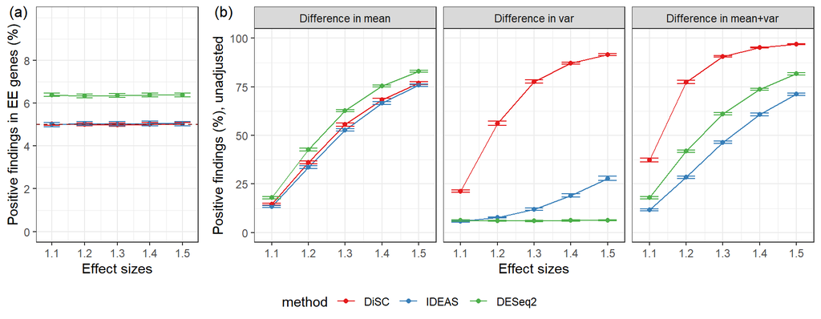

```r
ebw <- 0.05 #error bar width
DE1.1 <- p_raw %>%
  filter(n_cell  == 375, n_sample == 24,
         diff != 1, genestra != "Difference in EE") %>%
  mutate(values = values*100, sd = sd*100, se = se*100) %>%
  ggplot(aes(x=diff, y=values, color=method)) +
  facet_wrap(vars(genestra), ncol=3)+
  geom_point() + geom_line()+
  geom_errorbar(aes(ymin=values-1.96*se, ymax=values+1.96*se), width=ebw)+
  scale_color_brewer(palette = "Set1") +
  ylab("Positive findings (%), unadjusted") + xlab("Effect sizes")+ ylim(0,100)+
  theme_bw() +
  theme(legend.position="bottom")
EE1.1 <- p_raw %>%
  filter(n_cell  == 375, n_sample == 24,
         diff != 1, genestra == "Difference in EE") %>%
  mutate(values = values*100, sd = sd*100, se = se*100) %>%
  ggplot(aes(x=diff, y=values, color=method)) +
  geom_point() + geom_line()+
  geom_errorbar(aes(ymin=values-1.96*se, ymax=values+1.96*se), width=ebw)+
  geom_hline(yintercept=thre_raw*100, linetype="dashed", color = "firebrick4")+
  scale_color_brewer(palette = "Set1") +
  ylab("Positive findings in EE genes (%)") + xlab("Effect sizes")+
  scale_y_continuous(breaks = c(0,2,4,6,8), limits = c(0,10))+
  theme_bw() +
  theme(legend.position="bottom")

DE1.2 <- and_adj %>%
  filter(n_cell  == 375, n_sample == 24,
         diff != 1, genestra != "Difference in EE") %>%
  mutate(values = values/diff_ngene*100,
         sd = sd/diff_ngene*100, se = se/diff_ngene*100) %>%
  ggplot(aes(x=diff, y=values, color=method))  +
  facet_wrap(vars(genestra), nrow = 1, ncol=3)+
  geom_point() + geom_line()+
  geom_errorbar(aes(ymin=values-1.96*se, ymax=values+1.96*se), width=ebw)+
  scale_color_brewer(palette = "Set1") +
  ylab("Positive findings (%), adjusted") + xlab("Effect sizes")+ylim(0,100)+
  theme_bw() +
  theme(legend.position="bottom")

EE1.2 <- fdp_adj %>%
  filter(n_cell  == 375, n_sample == 24, diff != 1) %>%
  group_by(diff, n_sample, n_cell, neq_n_cell, method) %>%
  mutate(values = values*100, sd= sd*100, se = se*100) %>%
  ggplot(aes(x=diff, y=values, color=method))  +
  geom_point() + geom_line()+
  geom_errorbar(aes(ymin=values-1.96*se, ymax=values+1.96*se), width=ebw)+
  geom_hline(yintercept=thre_adj*100, linetype="dashed", color = "firebrick4")+
  scale_color_brewer(palette = "Set1") +
  ylab("False discovery proportion (%)") + xlab("Effect sizes")+ylim(0,65)+
  theme_bw() +
  theme(legend.position="bottom")

figure1.1 <- ggarrange(EE1.1, DE1.1,labels = c("(a)", "(b)"), widths = c(1,3),
                       legend = "bottom", common.legend = TRUE,
                       font.label = list(size = 12, color = "black",
                                         face = "plain", family = NULL))
figure1.1
```

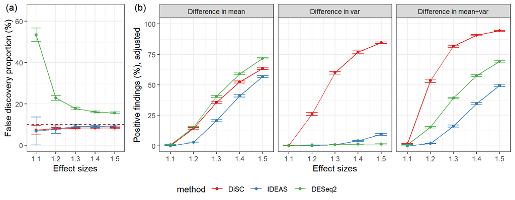

```r
ggsave(filename = "results/para_effectsize_raw.jpeg", figure1.1,
       width = 9, height = 3.5)
ggsave(filename = "results/para_effectsize_raw.pdf" , figure1.1,
       width = 9, height = 3.5)
figure1.2 <- ggarrange(EE1.2, DE1.2,labels = c("(a)", "(b)"), widths = c(1,3),
                       legend = "bottom", common.legend = TRUE,
                       font.label = list(size = 12, color = "black",
                                         face = "plain", family = NULL))
figure1.2
```

```r
ggsave(filename = "results/para_effectsize_fdr.jpeg", figure1.2,
       width = 9, height = 3.5)
ggsave(filename = "results/para_effectsize_fdr.pdf" , figure1.2,
       width = 9, height = 3.5)
```

- Scenario 2: Different cell numbers

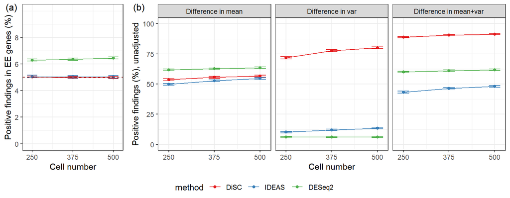

```r
ebw <- p_raw %>%
  filter(diff != 1) %>%
  summarise(ebw = 0.05*(max(n_cell) - min(n_cell)) / (max(diff) - min(diff)))%>%
  pull(ebw)
  #error bar width
NCELL <- p_raw %>%
  filter(diff != 1) %>%
  distinct(n_cell) %>%
  pull(n_cell) %>%
  sort()
DE2.1 <- p_raw %>%
  filter(diff  == 1.3, n_sample == 24,
         diff != 1, genestra != "Difference in EE") %>%
  mutate(values = values*100, sd = sd*100, se = se*100) %>%
  ggplot(aes(x=n_cell, y=values, color=method)) +
  facet_wrap(vars(genestra), ncol=3)+
  geom_point() + geom_line()+
  geom_errorbar(aes(ymin=values-1.96*se, ymax=values+1.96*se), width=ebw)+
  scale_color_brewer(palette = "Set1") +
  ylab("Positive findings (%), unadjusted") + xlab("Cell number")+
  ylim(0,100)+scale_x_continuous(breaks = NCELL)+
  theme_bw() +
  theme(legend.position="bottom")
EE2.1 <- p_raw %>%
  filter(diff  == 1.3, n_sample == 24,
         diff != 1, genestra == "Difference in EE") %>%
  mutate(values = values*100, sd = sd*100, se = se*100) %>%
  ggplot(aes(x=n_cell, y=values, color=method)) +
  geom_point() + geom_line()+
  geom_errorbar(aes(ymin=values-1.96*se, ymax=values+1.96*se), width=ebw)+
  geom_hline(yintercept=thre_raw*100, linetype="dashed", color = "firebrick4")+
  scale_color_brewer(palette = "Set1") +
  ylab("Positive findings in EE genes (%)") + xlab("Cell number")+
  scale_y_continuous(breaks = c(0,2,4,6,8), limits = c(0,10))+
  scale_x_continuous(breaks = NCELL)+
  theme_bw() +
  theme(legend.position="bottom")
DE2.2 <- and_adj %>%
  filter(diff  == 1.3, n_sample == 24,
         diff != 1, genestra != "Difference in EE") %>%
  mutate(values = values/diff_ngene*100,
         sd = sd/diff_ngene*100, se = se/diff_ngene*100) %>%
  ggplot(aes(x=n_cell, y=values, color=method))  +
  facet_wrap(vars(genestra), nrow = 1, ncol=3)+
  geom_point() + geom_line()+
  geom_errorbar(aes(ymin=values-1.96*se, ymax=values+1.96*se), width=ebw)+
  scale_color_brewer(palette = "Set1") +
  ylab("Positive findings (%), adjusted") + xlab("Cell number")+
  ylim(0,100)+scale_x_continuous(breaks = NCELL)+
  theme_bw() +
  theme(legend.position="bottom")
EE2.2 <- fdp_adj %>%
  filter(diff == 1.3, n_sample == 24, diff != 1) %>%
  group_by(diff, n_sample, n_cell, neq_n_cell, method) %>%
  mutate(values = values*100, sd= sd*100, se = se*100) %>%
  ggplot(aes(x=n_cell, y=values, color=method))  +
  geom_point() + geom_line()+
  geom_errorbar(aes(ymin=values-1.96*se, ymax=values+1.96*se), width=ebw)+
  geom_hline(yintercept=thre_adj*100, linetype="dashed", color = "firebrick4")+
  scale_color_brewer(palette = "Set1") +
  ylab("False discovery proportion (%)") + xlab("Cell number")+
  ylim(0,65)+scale_x_continuous(breaks = NCELL)+
  theme_bw() +
  theme(legend.position="bottom")


figure2.1 <- ggarrange(EE2.1, DE2.1,labels = c("(a)", "(b)"), widths = c(1,3),
                       legend = "bottom", common.legend = TRUE,
                       font.label = list(size = 12, color = "black",
                                         face = "plain", family = NULL))
figure2.1
```

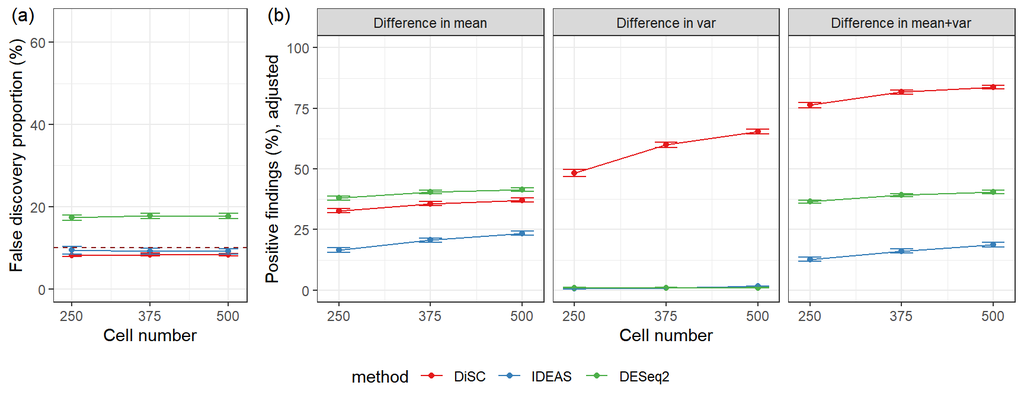

```r
ggsave(filename = "results/para_cellnum_raw.jpeg", figure2.1,
       width = 9, height = 3.5)
ggsave(filename = "results/para_cellnum_raw.pdf" , figure2.1,
       width = 9, height = 3.5)

figure2.2 <- ggarrange(EE2.2, DE2.2,labels = c("(a)", "(b)"), widths = c(1,3),
                       legend = "bottom", common.legend = TRUE,
                       font.label = list(size = 12, color = "black",
                                         face = "plain", family = NULL))
figure2.2
```

```r
ggsave(filename = "results/para_cellnum_fdr.jpeg", figure2.2,
       width = 9, height = 3.5)
ggsave(filename = "results/para_cellnum_fdr.pdf" , figure2.2,
       width = 9, height = 3.5)
```

- Scenario 3: different sample sizes

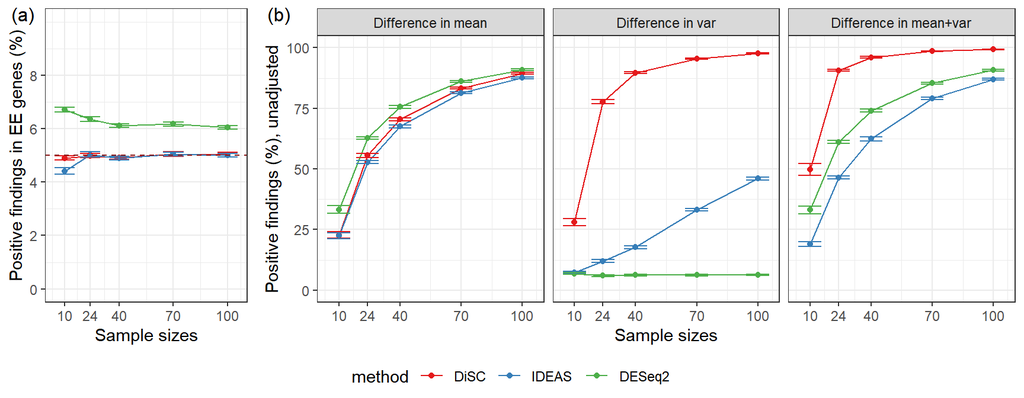

```r
ebw <- p_raw %>%
  filter(diff != 1) %>%
  summarise(ebw = 0.05*(max(n_sample) - min(n_sample)) / (max(diff) - min(diff)))%>%
  pull(ebw)
  #error bar width
NSAMPLE <- p_raw %>%
  filter(diff != 1) %>%
  distinct(n_sample) %>%
  pull(n_sample) %>%
  sort()
DE3.1 <- p_raw %>%
  filter(diff  == 1.3, n_cell == 375,
         diff != 1, genestra != "Difference in EE") %>%
  mutate(values = values*100, sd = sd*100, se = se*100) %>%
  ggplot(aes(x=n_sample, y=values, color=method)) +
  facet_wrap(vars(genestra), ncol=3)+
  geom_point() + geom_line()+
  geom_errorbar(aes(ymin=values-1.96*se, ymax=values+1.96*se), width=ebw)+
  scale_color_brewer(palette = "Set1") +
  ylab("Positive findings (%), unadjusted") + xlab("Sample sizes")+
  ylim(0,100)+scale_x_continuous(breaks = NSAMPLE)+
  theme_bw() +
  theme(legend.position="bottom")
EE3.1 <- p_raw %>%
  filter(diff  == 1.3, n_cell == 375,
         diff != 1, genestra == "Difference in EE") %>%
  mutate(values = values*100, sd = sd*100, se = se*100) %>%
  ggplot(aes(x=n_sample, y=values, color=method)) +
  geom_point() + geom_line()+
  geom_errorbar(aes(ymin=values-1.96*se, ymax=values+1.96*se), width=ebw)+
  geom_hline(yintercept=thre_raw*100, linetype="dashed", color = "firebrick4")+
  scale_color_brewer(palette = "Set1") +
  ylab("Positive findings in EE genes (%)") + xlab("Sample sizes")+
  scale_y_continuous(breaks = c(0,2,4,6,8), limits = c(0,10))+
  scale_x_continuous(breaks = NSAMPLE)+
  theme_bw() +
  theme(legend.position="bottom")
DE3.2 <- and_adj %>%
  filter(diff  == 1.3, n_cell == 375,
         diff != 1, genestra != "Difference in EE") %>%
  mutate(values = values/diff_ngene*100,
         sd = sd/diff_ngene*100, se = se/diff_ngene*100) %>%
  ggplot(aes(x=n_sample, y=values, color=method))  +
  facet_wrap(vars(genestra), nrow = 1, ncol=3)+
  geom_point() + geom_line()+
  geom_errorbar(aes(ymin=values-1.96*se, ymax=values+1.96*se), width=ebw)+
  scale_color_brewer(palette = "Set1") +
  ylab("Positive findings (%), adjusted") + xlab("Sample sizes")+
  ylim(0,100)+scale_x_continuous(breaks = NSAMPLE)+
  theme_bw() +
  theme(legend.position="bottom")
EE3.2 <- fdp_adj %>%
  filter(diff == 1.3, n_cell == 375, diff != 1) %>%
  group_by(diff, n_sample, n_cell, neq_n_cell, method) %>%
  mutate(values = values*100, sd= sd*100, se = se*100) %>%
  ggplot(aes(x=n_sample, y=values, color=method))  +
  geom_point() + geom_line()+
  geom_errorbar(aes(ymin=values-1.96*se, ymax=values+1.96*se), width=ebw)+
  geom_hline(yintercept=thre_adj*100, linetype="dashed", color = "firebrick4")+
  scale_color_brewer(palette = "Set1") +
  ylab("False discovery proportion (%)") + xlab("Sample sizes")+
  ylim(0,65)+scale_x_continuous(breaks = NSAMPLE)+
  theme_bw() +
  theme(legend.position="bottom")



figure3.1 <- ggarrange(EE3.1, DE3.1,labels = c("(a)", "(b)"), widths = c(1,3),
                       legend = "bottom", common.legend = TRUE,
                       font.label = list(size = 12, color = "black",
                                         face = "plain", family = NULL))
figure3.1
```

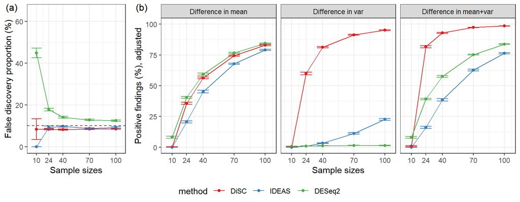

```r
ggsave(filename = "results/para_samplesize_raw.jpeg", figure3.1,
       width = 9, height = 3.5)
ggsave(filename = "results/para_samplesize_raw.pdf" , figure3.1,
       width = 9, height = 3.5)

figure3.2 <- ggarrange(EE3.2, DE3.2,labels = c("(a)", "(b)"), widths = c(1,3),
                       legend = "bottom", common.legend = TRUE,
                       font.label = list(size = 12, color = "black",
                                         face = "plain", family = NULL))
figure3.2
```

```r
ggsave(filename = "results/para_samplesize_fdr.jpeg", figure3.2,
       width = 9, height = 3.5)
ggsave(filename = "results/para_samplesize_fdr.pdf" , figure3.2,
       width = 9, height = 3.5)
```

- Scenario 4: type I error and FDR

```r
tbl.temp <- FDR_results %>%
  select(method, p_raw, fdr, ANFD) %>%
  rename("Type I error rate (%)" = p_raw) %>%
  rename("False discovery proportions (%)" = fdr) %>%
  rename("Average number of false positive fundings" = ANFD) %>%
  kbl() %>%
  kable_classic(full_width = F, html_font = "Cambria")
tbl.temp
```

| method | Type I error rate (%) | False discovery proportions (%) | Average number of false positive fundings |
| --- | --- | --- | --- |
| DiSC | 5.01 (5.02, 4.99) | 9.1 (7.5, 11) | 0.1 (0.1, 0.1) |
| IDEAS | 5.02 (5.04, 5) | 7.9 (6.4, 9.7) | 0.1 (0.1, 0.1) |
| DESeq2 | 6.36 (6.38, 6.35) | 91.1 (89.2, 92.7) | 5.9 (6.2, 5.6) |

```r
save_kable(tbl.temp, file = "results/para_null_fdr.jpeg",
           density = 1000, zoom = 2.5)
```

## 4.4 References

- Zhang, M., et al. IDEAS: individual level differential expression analysis for single-cell RNA-seq data. Genome Biol 23, 33 (2022). https://doi.org/10.1186/s13059-022-02605-1.
- Velmeshev, D., et al. Single-cell genomics identifies cell type–specific molecular changes in autism. Science 364.6441 (2019): 685-689.
- Eraslan, G., et al. Single-cell RNA-seq denoising using a deep count autoencoder. Nature communications 10.1 (2019): 1-14.